# RST Data checks - DB vs EDI

#### release

**- Findings:**

- Date ranges are the same
- no fork_length or lifestage in EDI data

```
## Rows: 49
## Columns: 12
## $ id                          <int> 63014, 63015, 63016, 63017, 63018, 63019, …
## $ trap_location_id            <int> 50, 50, 50, 50, 50, 50, 50, 50, 50, 50, 50…
## $ release_id                  <chr> "266", "265", "267", "268", "269", "270", …
## $ date_released               <dttm> 2023-03-08 13:30:12, 2023-03-08 13:30:12,…
## $ run_id                      <int> 3, 3, 3, 3, 3, 3, 3, 3, 3, 3, 3, 3, 3, 3, …
## $ median_fork_length_released <dbl> NA, NA, NA, NA, NA, NA, NA, NA, NA, NA, NA…
## $ lifestage_id                <int> NA, NA, NA, NA, NA, NA, NA, NA, NA, NA, NA…
## $ origin_id                   <int> 1, 2, 2, 2, 2, 2, 2, 2, 2, 2, 1, 1, 1, 1, …
## $ number_released             <dbl> 290, 509, 999, 1002, 1015, 1021, 999, 1048…
## $ updated_at                  <dttm> 2025-06-09 09:00:13, 2025-06-09 09:00:13,…
## $ updated_by                  <chr> "AdminJPE", "AdminJPE", "AdminJPE", "Admin…
## $ stream                      <chr> "yuba river", "yuba river", "yuba river", …
```

```
## [1] "2023-01-19 22:27:12 UTC" "2025-02-26 00:00:12 UTC"
```

*number_released or nReleased*

DB

```
##    Min. 1st Qu.  Median    Mean 3rd Qu.    Max.
##    22.0   320.0   567.0   661.9   997.0  2018.0
```

EDI

```
##    Min. 1st Qu.  Median    Mean 3rd Qu.    Max.    NA's
##    22.0   320.0   567.0   661.9   997.0  2018.0       1
```

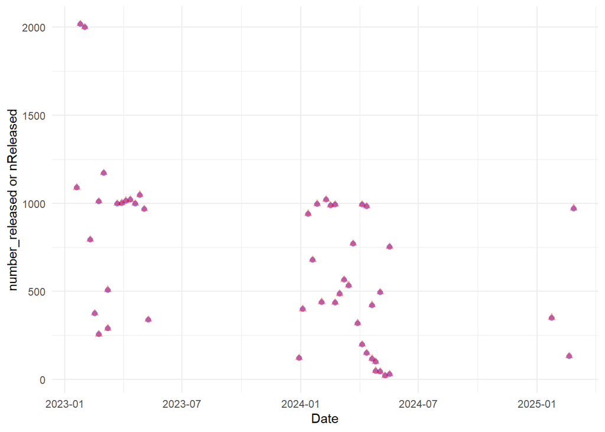

Random pick of data entry to compare between db and EDI

test 1

```
## Rows: 1
## Columns: 12
## $ id                          <int> 63038
## $ trap_location_id            <int> 50
## $ release_id                  <chr> "290"
## $ date_released               <dttm> 2024-03-29 11:11:12
## $ run_id                      <int> 3
## $ median_fork_length_released <dbl> NA
## $ lifestage_id                <int> NA
## $ origin_id                   <int> 1
## $ number_released             <dbl> 320
## $ updated_at                  <dttm> 2025-06-09 09:00:13
## $ updated_by                  <chr> "AdminJPE"
## $ stream                      <chr> "yuba river"
```

```
## Rows: 1
## Columns: 16
## $ projectDescriptionID <dbl> 7
## $ releaseID            <dbl> 290
## $ releaseTime          <dttm> 2024-03-29 11:11:12
## $ commonName           <chr> "Chinook salmon"
## $ markedRun            <chr> "Fall"
## $ markedFishOrigin     <chr> "Natural"
## $ sourceOfFishSite     <chr> "Hallwood"
## $ releaseSite          <chr> "Hallwood Release Site"
## $ releaseSubSite       <lgl> NA
## $ nReleased            <dbl> 320
## $ testDays             <dbl> 7
## $ appliedMarkType      <chr> "Elastomer"
## $ appliedMarkColor     <chr> "Yellow"
## $ appliedMarkPosition  <chr> "Nose"
## $ appliedMarkCode      <lgl> NA
## $ IncludeInAnalysis    <chr> "Yes"
```

test 2

```
## Rows: 1
## Columns: 12
## $ id                          <int> 63049
## $ trap_location_id            <int> 50
## $ release_id                  <chr> "303"
## $ date_released               <dttm> 2024-05-10 12:16:12
## $ run_id                      <int> 3
## $ median_fork_length_released <dbl> NA
## $ lifestage_id                <int> NA
## $ origin_id                   <int> 1
## $ number_released             <dbl> 22
## $ updated_at                  <dttm> 2025-06-09 09:00:13
## $ updated_by                  <chr> "AdminJPE"
## $ stream                      <chr> "yuba river"
```

```
## Rows: 1
## Columns: 16
## $ projectDescriptionID <dbl> 7
## $ releaseID            <dbl> 303
## $ releaseTime          <dttm> 2024-05-10 12:16:12
## $ commonName           <chr> "Chinook salmon"
## $ markedRun            <chr> "Fall"
## $ markedFishOrigin     <chr> "Natural"
## $ sourceOfFishSite     <chr> "Hallwood"
## $ releaseSite          <chr> "Hallwood Release Site"
## $ releaseSubSite       <lgl> NA
## $ nReleased            <dbl> 22
## $ testDays             <dbl> 7
## $ appliedMarkType      <chr> "Elastomer"
## $ appliedMarkColor     <chr> "Yellow"
## $ appliedMarkPosition  <chr> "Nose"
## $ appliedMarkCode      <lgl> NA
## $ IncludeInAnalysis    <chr> "Yes"
```

test 3

```
## Rows: 1
## Columns: 12
## $ id                          <int> 63023
## $ trap_location_id            <int> 50
## $ release_id                  <chr> "274"
## $ date_released               <dttm> 2023-05-10 10:00:12
## $ run_id                      <int> 3
## $ median_fork_length_released <dbl> NA
## $ lifestage_id                <int> NA
## $ origin_id                   <int> 2
## $ number_released             <dbl> 340
## $ updated_at                  <dttm> 2025-06-09 09:00:13
## $ updated_by                  <chr> "AdminJPE"
## $ stream                      <chr> "yuba river"
```

```
## Rows: 1
## Columns: 16
## $ projectDescriptionID <dbl> 7
## $ releaseID            <dbl> 274
## $ releaseTime          <dttm> 2023-05-10 10:00:12
## $ commonName           <chr> "Chinook salmon"
## $ markedRun            <chr> "Fall"
## $ markedFishOrigin     <chr> "Hatchery"
## $ sourceOfFishSite     <chr> "Not recorded"
## $ releaseSite          <chr> "Hallwood Release Site"
## $ releaseSubSite       <lgl> NA
## $ nReleased            <dbl> 340
## $ testDays             <dbl> 7
## $ appliedMarkType      <chr> "Elastomer"
## $ appliedMarkColor     <chr> "Pink"
## $ appliedMarkPosition  <chr> "Nose"
## $ appliedMarkCode      <lgl> NA
## $ IncludeInAnalysis    <chr> "Yes"
```

test 4

```
## Rows: 1
## Columns: 12
## $ id                          <int> 63008
## $ trap_location_id            <int> 50
## $ release_id                  <chr> "259"
## $ date_released               <dttm> 2023-02-01 12:15:12
## $ run_id                      <int> 3
## $ median_fork_length_released <dbl> NA
## $ lifestage_id                <int> NA
## $ origin_id                   <int> 2
## $ number_released             <dbl> 2001
## $ updated_at                  <dttm> 2025-06-09 09:00:13
## $ updated_by                  <chr> "AdminJPE"
## $ stream                      <chr> "yuba river"
```

```
## Rows: 1
## Columns: 16
## $ projectDescriptionID <dbl> 7
## $ releaseID            <dbl> 259
## $ releaseTime          <dttm> 2023-02-01 12:15:12
## $ commonName           <chr> "Chinook salmon"
## $ markedRun            <chr> "Fall"
## $ markedFishOrigin     <chr> "Hatchery"
## $ sourceOfFishSite     <chr> "Not recorded"
## $ releaseSite          <chr> "Hallwood Release Site"
## $ releaseSubSite       <lgl> NA
## $ nReleased            <dbl> 2001
## $ testDays             <dbl> 7
## $ appliedMarkType      <chr> "Pigment / dye"
## $ appliedMarkColor     <chr> "Brown"
## $ appliedMarkPosition  <chr> "Whole body"
## $ appliedMarkCode      <lgl> NA
## $ IncludeInAnalysis    <chr> "Yes"
```

#### recapture

**- Findings:** - Date range is the same - Same percentage of fork length and lifetage NA values - lifestage categories are the same

- Database

```
## [1] "2023-01-20" "2024-05-18"
```

- EDI

```
## Rows: 308
## Columns: 18
## $ ProjectDescriptionID <dbl> 7, 7, 7, 7, 7, 7, 7, 7, 7, 7, 7, 7, 7, 7, 7, 7, 7…
## $ catchRawID           <dbl> 2009, 2343, 2361, 2961, 3015, 3085, 3128, 3187, 3…
## $ trapVisitID          <dbl> 118, 129, 130, 150, 151, 152, 153, 154, 170, 174,…
## $ commonName           <chr> "Chinook salmon", "Chinook salmon", "Chinook salm…
## $ releaseID            <dbl> 257, 258, 258, 259, 259, 259, 259, 259, 260, 260,…
## $ run                  <lgl> NA, NA, NA, NA, NA, NA, NA, NA, NA, NA, NA, NA, N…
## $ fishOrigin           <chr> "Hatchery", "Hatchery", "Hatchery", "Hatchery", "…
## $ lifeStage            <chr> "Not recorded", "Not recorded", "Not recorded", "…
## $ forkLength           <dbl> NA, NA, NA, NA, NA, NA, NA, NA, NA, NA, NA, NA, N…
## $ n                    <dbl> 1, 15, 8, 15, 10, 15, 3, 18, 11, 2, 10, 2, 37, 1,…
## $ visitTime            <dttm> 2023-01-20 09:00:57, 2023-01-26 09:00:08, 2023-0…
## $ visitType            <chr> "Continue trapping", "Continue trapping", "Contin…
## $ siteName             <chr> "Hallwood", "Hallwood", "Hallwood", "Hallwood", "…
## $ subSiteName          <chr> "Hallwood 1 RR", "Hallwood 1 RR", "Hallwood 2 RL"…
## $ markType             <chr> "Pigment / dye", "Pigment / dye", "Pigment / dye"…
## $ markColor            <chr> "Brown", "Brown", "Brown", "Brown", "Brown", "Bro…
## $ markPosition         <chr> "Whole body", "Whole body", "Whole body", "Whole …
## $ markCode             <lgl> NA, NA, NA, NA, NA, NA, NA, NA, NA, NA, NA, NA, N…
```

```
## [1] "2023-01-20 09:00:57 UTC" "2024-05-18 10:26:37 UTC"
```

column names DB

```
##  [1] "id"               "trap_location_id" "catch_raw_id"     "date"
##  [5] "count"            "run_id"           "lifestage_id"     "adipose_clipped"
##  [9] "dead"             "fork_length"      "weight"           "release_id"
## [13] "updated_at"       "stream"
```

column names EDI

```
##  [1] "ProjectDescriptionID" "catchRawID"           "trapVisitID"
##  [4] "commonName"           "releaseID"            "run"
##  [7] "fishOrigin"           "lifeStage"            "forkLength"
## [10] "n"                    "visitTime"            "visitType"
## [13] "siteName"             "subSiteName"          "markType"
## [16] "markColor"            "markPosition"         "markCode"
```

*date vs count/number_recapture*

- 0 % of values in the `count` column from the database are NA.
- 0 % of values in the `n` column from EDI are NA.

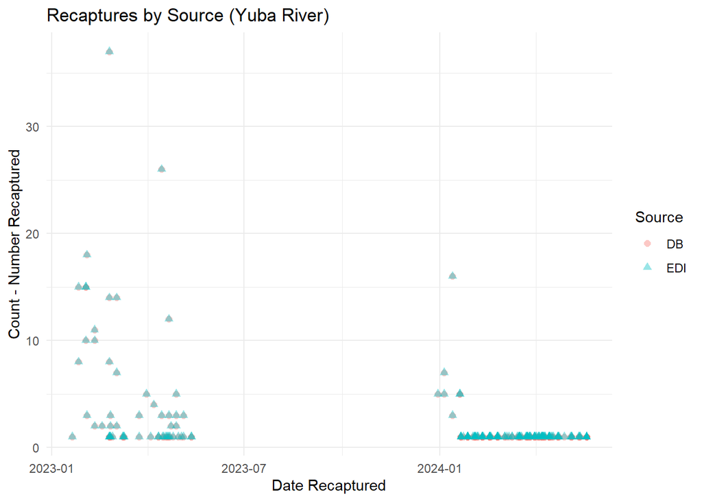

*fork_length*

- 21.1 % of values in the `fork_length` column from the database are NA.
- 21.1 % of values in the `forkLength` column from EDI are NA.

*lifestage*

- 0 % of values in the `lifestage_id` column from the database are NA.
- 0 % of values in the `lifeStage` column from EDI are NA.

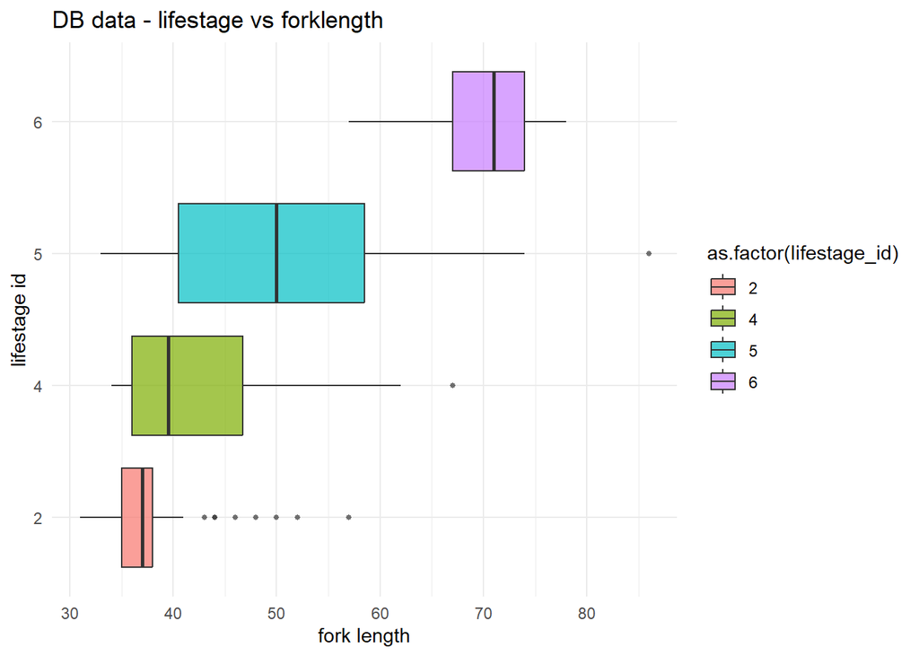

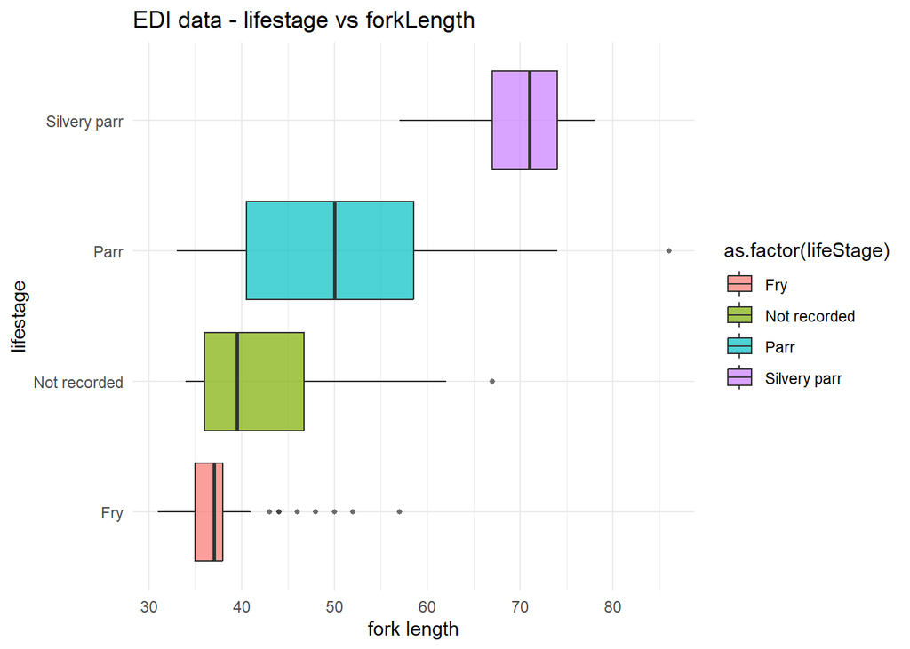

Random pick of data entry to compare between DB and EDI

- test 1

```
## Rows: 1
## Columns: 15
## $ id               <int> 243923
## $ trap_location_id <int> 48
## $ catch_raw_id     <int> 4119
## $ date             <date> 2023-02-10
## $ count            <dbl> 2
## $ run_id           <int> 5
## $ lifestage_id     <int> 4
## $ adipose_clipped  <lgl> FALSE
## $ dead             <lgl> NA
## $ fork_length      <dbl> NA
## $ weight           <dbl> NA
## $ release_id       <chr> "260"
## $ updated_at       <dttm> 2025-06-09 09:00:12
## $ stream           <chr> "yuba river"
## $ source           <chr> "DB"
```

```
## Rows: 1
## Columns: 21
## $ ProjectDescriptionID <dbl> 7
## $ catchRawID           <dbl> 4119
## $ trapVisitID          <dbl> 174
## $ commonName           <chr> "Chinook salmon"
## $ releaseID            <dbl> 260
## $ run                  <lgl> NA
## $ fishOrigin           <chr> "Natural"
## $ lifeStage            <chr> "Not recorded"
## $ forkLength           <dbl> NA
## $ n                    <dbl> 2
## $ visitTime            <dttm> 2023-02-10 09:25:44
## $ visitType            <chr> "Continue trapping"
## $ siteName             <chr> "Hallwood"
## $ subSiteName          <chr> "Hallwood 2 RL"
## $ markType             <chr> "Elastomer"
## $ markColor            <chr> "Yellow"
## $ markPosition         <chr> "Nose"
## $ markCode             <lgl> NA
## $ source               <chr> "EDI"
## $ date                 <date> 2023-02-10
## $ count                <dbl> 2
```

- test 2

```
## Rows: 1
## Columns: 15
## $ id               <int> 244008
## $ trap_location_id <int> 47
## $ catch_raw_id     <int> 17556
## $ date             <date> 2024-02-03
## $ count            <dbl> 1
## $ run_id           <int> 5
## $ lifestage_id     <int> 2
## $ adipose_clipped  <lgl> FALSE
## $ dead             <lgl> NA
## $ fork_length      <dbl> 37
## $ weight           <dbl> NA
## $ release_id       <chr> "280"
## $ updated_at       <dttm> 2025-06-09 09:00:12
## $ stream           <chr> "yuba river"
## $ source           <chr> "DB"
```

```
## Rows: 1
## Columns: 21
## $ ProjectDescriptionID <dbl> 7
## $ catchRawID           <dbl> 17556
## $ trapVisitID          <dbl> 908
## $ commonName           <chr> "Chinook salmon"
## $ releaseID            <dbl> 280
## $ run                  <lgl> NA
## $ fishOrigin           <chr> "Natural"
## $ lifeStage            <chr> "Fry"
## $ forkLength           <dbl> 37
## $ n                    <dbl> 1
## $ visitTime            <dttm> 2024-02-03 10:30:46
## $ visitType            <chr> "Continue trapping"
## $ siteName             <chr> "Hallwood"
## $ subSiteName          <chr> "Hallwood 1 RR"
## $ markType             <chr> "Elastomer"
## $ markColor            <chr> "Yellow"
## $ markPosition         <chr> "Nose"
## $ markCode             <lgl> NA
## $ source               <chr> "EDI"
## $ date                 <date> 2024-02-03
## $ count                <dbl> 1
```

- test 3

```
## Rows: 1
## Columns: 15
## $ id               <int> 243970
## $ trap_location_id <int> 47
## $ catch_raw_id     <int> 10663
## $ date             <date> 2023-05-12
## $ count            <dbl> 1
## $ run_id           <int> 5
## $ lifestage_id     <int> 4
## $ adipose_clipped  <lgl> TRUE
## $ dead             <lgl> NA
## $ fork_length      <dbl> NA
## $ weight           <dbl> NA
## $ release_id       <chr> "274"
## $ updated_at       <dttm> 2025-06-09 09:00:12
## $ stream           <chr> "yuba river"
## $ source           <chr> "DB"
```

```
## Rows: 1
## Columns: 21
## $ ProjectDescriptionID <dbl> 7
## $ catchRawID           <dbl> 10663
## $ trapVisitID          <dbl> 434
## $ commonName           <chr> "Chinook salmon"
## $ releaseID            <dbl> 274
## $ run                  <lgl> NA
## $ fishOrigin           <chr> "Hatchery"
## $ lifeStage            <chr> "Not recorded"
## $ forkLength           <dbl> NA
## $ n                    <dbl> 1
## $ visitTime            <dttm> 2023-05-12 08:52:57
## $ visitType            <chr> "Continue trapping"
## $ siteName             <chr> "Hallwood"
## $ subSiteName          <chr> "Hallwood 1 RR"
## $ markType             <chr> "Elastomer"
## $ markColor            <chr> "Pink"
## $ markPosition         <chr> "Nose"
## $ markCode             <lgl> NA
## $ source               <chr> "EDI"
## $ date                 <date> 2023-05-12
## $ count                <dbl> 1
```

- test 4

```
## Rows: 1
## Columns: 15
## $ id               <int> 244220
## $ trap_location_id <int> 48
## $ catch_raw_id     <int> 29902
## $ date             <date> 2024-05-18
## $ count            <dbl> 1
## $ run_id           <int> 5
## $ lifestage_id     <int> 4
## $ adipose_clipped  <lgl> FALSE
## $ dead             <lgl> NA
## $ fork_length      <dbl> 67
## $ weight           <dbl> NA
## $ release_id       <chr> "304"
## $ updated_at       <dttm> 2025-06-09 09:00:12
## $ stream           <chr> "yuba river"
## $ source           <chr> "DB"
```

```
## Rows: 1
## Columns: 21
## $ ProjectDescriptionID <dbl> 7
## $ catchRawID           <dbl> 29902
## $ trapVisitID          <dbl> 1228
## $ commonName           <chr> "Chinook salmon"
## $ releaseID            <dbl> 304
## $ run                  <lgl> NA
## $ fishOrigin           <chr> "Natural"
## $ lifeStage            <chr> "Not recorded"
## $ forkLength           <dbl> 67
## $ n                    <dbl> 1
## $ visitTime            <dttm> 2024-05-18 10:26:37
## $ visitType            <chr> "Continue trapping"
## $ siteName             <chr> "Hallwood"
## $ subSiteName          <chr> "Hallwood 2 RL"
## $ markType             <chr> "Elastomer"
## $ markColor            <chr> "Pink"
## $ markPosition         <chr> "Nose"
## $ markCode             <lgl> NA
## $ source               <chr> "EDI"
## $ date                 <date> 2024-05-18
## $ count                <dbl> 1
```

### Sacramento/Knights landing

#### catch

**- Findings:** - Date range is not the same (edi earliest year is 2003 and database is 2021) - There are a lot of NA fork length values on EDI - lifestage has more categories in EDI data

- Database date range

```r
catch_knights_db <- catch_with_stream |>
  filter(trap_location_id %in% c(51, 52, 53, 54)) # trap id for Sacramento/Knights landing

range(catch_knights_db$date)
```

```
## [1] "2021-09-24" "2025-04-17"
```

- EDI date range

```
## [1] "2003-12-27 10:00:43 UTC" "2025-04-17 10:45:04 UTC"
```

*fork_length*

EDI

- 34.1 % of values in the `forkLength` column are NA.

```
##    Min. 1st Qu.  Median    Mean 3rd Qu.    Max.    NA's
##     1.0    37.0    40.0    54.1    71.0   991.0   61696
```

DB

- 4.9 % of values in the `fork_length` column are NA.

```
##    Min. 1st Qu.  Median    Mean 3rd Qu.    Max.    NA's
##     1.0    37.0    39.0    51.4    71.0   686.0     835
```

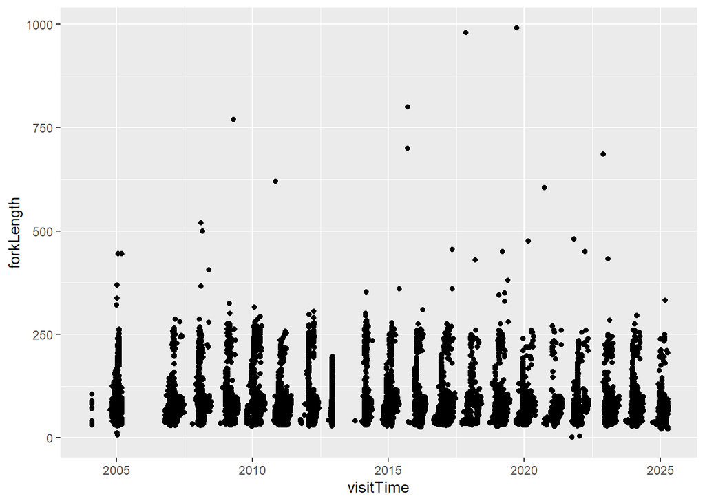

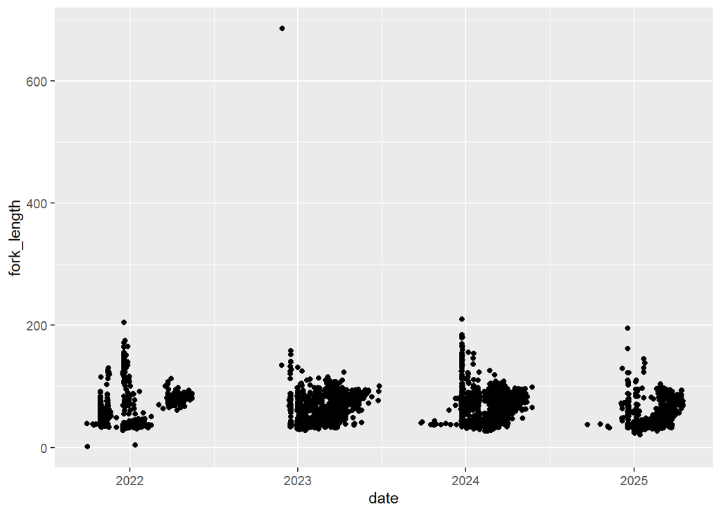

filtering only matching years (2021 onwards)

exploration plots

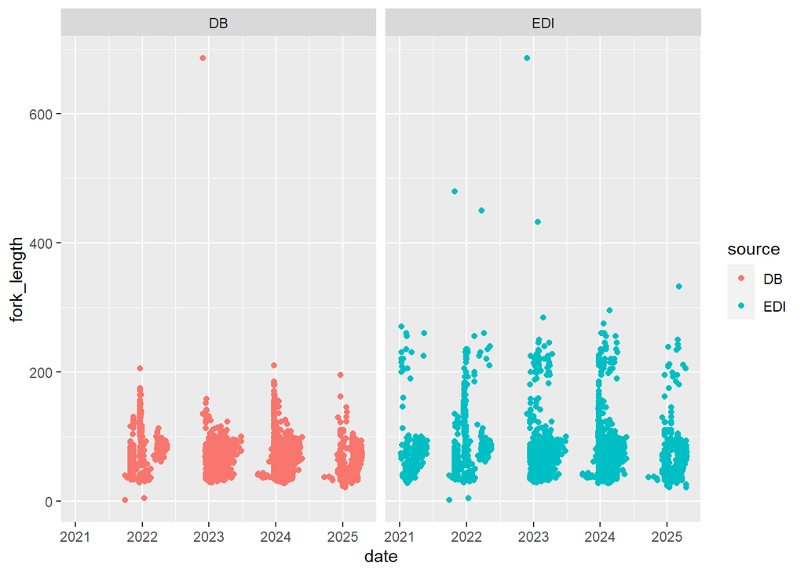

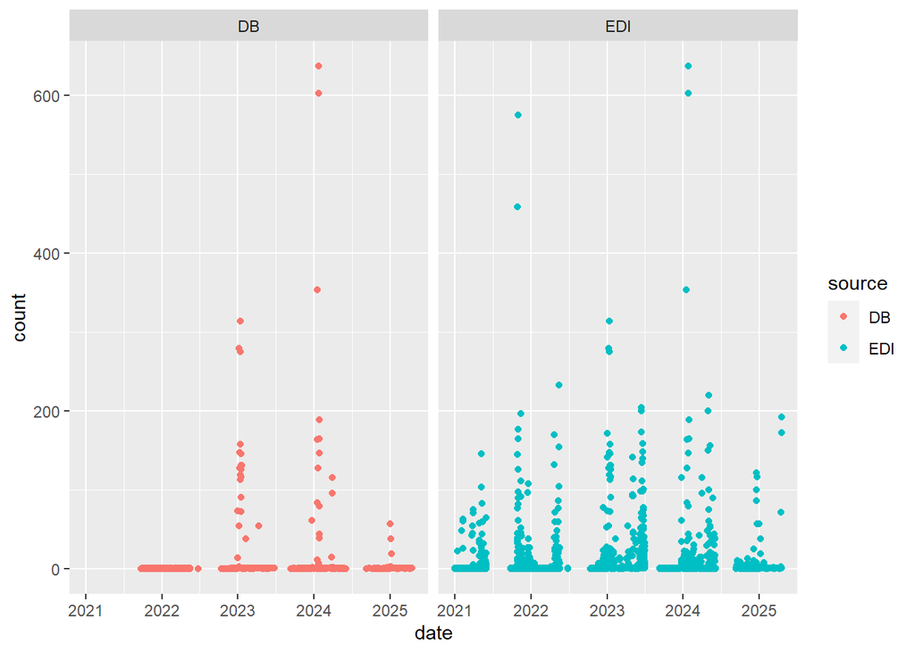

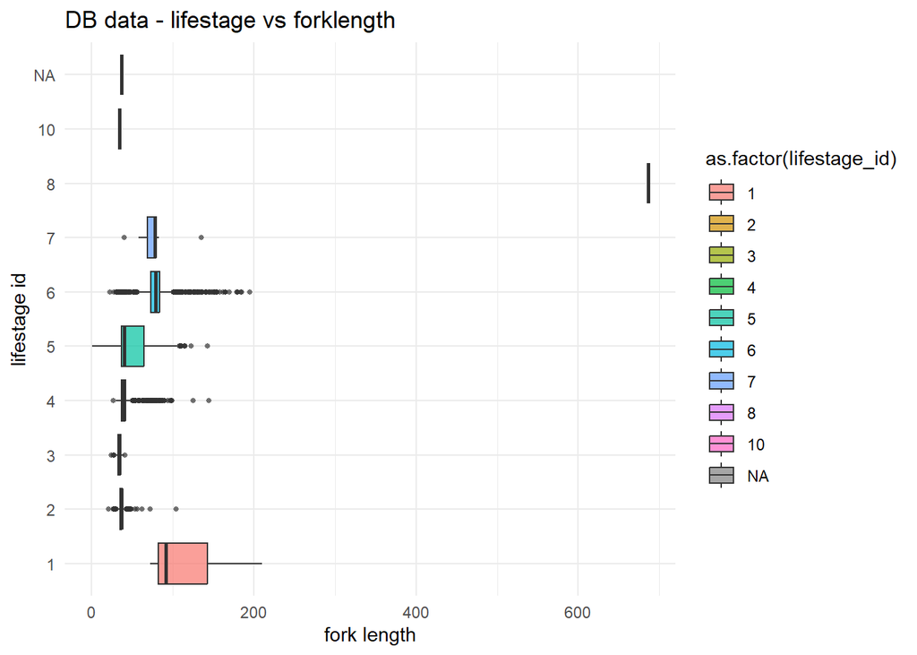

- 0 % of values in the `lifeStage` column from EDI are NA.

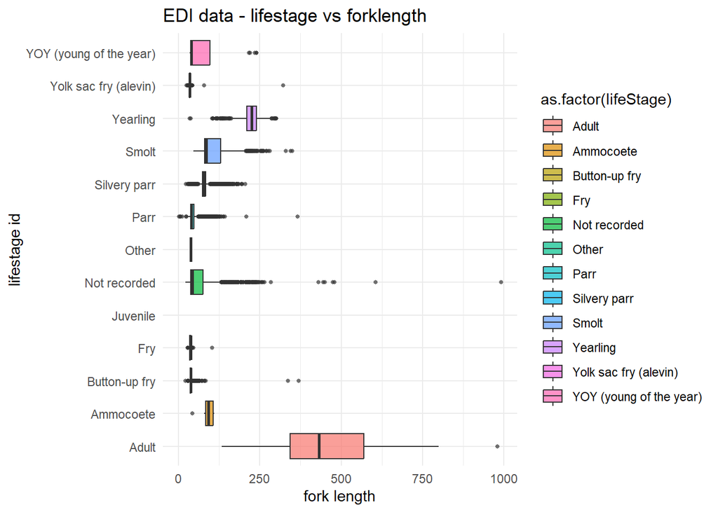

Random pick of data entry to compare between db and EDI

Test 1

```
## Rows: 1
## Columns: 14
## $ id               <int> 45944175
## $ catch_raw_id     <chr> "144738"
## $ trap_location_id <int> 51
## $ date             <date> 2021-10-08
## $ count            <dbl> 0
## $ run_id           <int> 5
## $ lifestage_id     <int> 7
## $ adipose_clipped  <lgl> FALSE
## $ dead             <lgl> TRUE
## $ fork_length      <dbl> NA
## $ weight           <dbl> NA
## $ actual_count     <lgl> TRUE
## $ updated_at       <dttm> 2025-06-09 09:05:21
## $ stream           <chr> "sacramento river"
```

```
## Rows: 1
## Columns: 19
## $ ProjectDescriptionID <dbl> 9
## $ trapVisitID          <dbl> 6889
## $ visitTime            <dttm> 2021-10-08 10:30:09
## $ visitTime2           <dttm> 2021-10-08 10:30:09
## $ siteName             <chr> "Knights Landing RST"
## $ subSiteName          <dbl> 8.3
## $ visitType            <chr> "Unplanned restart"
## $ catchRawID           <dbl> 144738
## $ commonName           <chr> "Chinook salmon"
## $ releaseID            <dbl> 0
## $ run                  <chr> NA
## $ fishOrigin           <chr> "Natural"
## $ lifeStage            <chr> "Not recorded"
## $ forkLength           <dbl> NA
## $ totalLength          <dbl> NA
## $ weight               <dbl> NA
## $ n                    <dbl> 0
## $ trap_start_date      <dttm> 2021-10-07 10:55:34
## $ trap_end_date        <dttm> 2021-10-08 10:30:09
```

test 2

```
## Rows: 1
## Columns: 14
## $ id               <int> 45951216
## $ catch_raw_id     <chr> "171057"
## $ trap_location_id <int> 51
## $ date             <date> 2024-04-05
## $ count            <dbl> 1
## $ run_id           <int> 5
## $ lifestage_id     <int> 6
## $ adipose_clipped  <lgl> FALSE
## $ dead             <lgl> TRUE
## $ fork_length      <dbl> 73
## $ weight           <dbl> NA
## $ actual_count     <lgl> TRUE
## $ updated_at       <dttm> 2025-06-09 09:05:21
## $ stream           <chr> "sacramento river"
```

```
## Rows: 1
## Columns: 19
## $ ProjectDescriptionID <dbl> 9
## $ trapVisitID          <dbl> 8283
## $ visitTime            <dttm> 2024-04-05 10:15:18
## $ visitTime2           <dttm> 2024-04-05 10:15:18
## $ siteName             <chr> "Knights Landing RST"
## $ subSiteName          <dbl> 8.3
## $ visitType            <chr> "Continue trapping"
## $ catchRawID           <dbl> 171057
## $ commonName           <chr> "Chinook salmon"
## $ releaseID            <dbl> 255
## $ run                  <chr> NA
## $ fishOrigin           <chr> "Natural"
## $ lifeStage            <chr> "Silvery parr"
## $ forkLength           <dbl> 73
## $ totalLength          <dbl> NA
## $ weight               <dbl> NA
## $ n                    <dbl> 1
## $ trap_start_date      <dttm> 2024-04-04 09:45:04
## $ trap_end_date        <dttm> 2024-04-05 10:15:18
```

test 3

```
## Rows: 1
## Columns: 14
## $ id               <int> 45955726
## $ catch_raw_id     <chr> "156696"
## $ trap_location_id <int> 52
## $ date             <date> 2023-01-26
## $ count            <dbl> 1
## $ run_id           <int> 3
## $ lifestage_id     <int> 5
## $ adipose_clipped  <lgl> FALSE
## $ dead             <lgl> TRUE
## $ fork_length      <dbl> 40
## $ weight           <dbl> NA
## $ actual_count     <lgl> TRUE
## $ updated_at       <dttm> 2025-06-09 09:05:21
## $ stream           <chr> "sacramento river"
```

```
## Rows: 1
## Columns: 19
## $ ProjectDescriptionID <dbl> 9
## $ trapVisitID          <dbl> 7519
## $ visitTime            <dttm> 2023-01-26 10:00:09
## $ visitTime2           <dttm> 2023-01-26 10:00:09
## $ siteName             <chr> "Knights Landing RST"
## $ subSiteName          <dbl> 8.4
## $ visitType            <chr> "Continue trapping"
## $ catchRawID           <dbl> 156696
## $ commonName           <chr> "Chinook salmon"
## $ releaseID            <dbl> 0
## $ run                  <chr> "Fall"
## $ fishOrigin           <chr> "Natural"
## $ lifeStage            <chr> "Parr"
## $ forkLength           <dbl> 40
## $ totalLength          <dbl> NA
## $ weight               <dbl> NA
## $ n                    <dbl> 1
## $ trap_start_date      <dttm> 2023-01-25 10:15:45
## $ trap_end_date        <dttm> 2023-01-26 10:00:09
```

test 4

```
## Rows: 1
## Columns: 14
## $ id               <int> 45958585
## $ catch_raw_id     <chr> "167894"
## $ trap_location_id <int> 52
## $ date             <date> 2024-02-11
## $ count            <dbl> 1
## $ run_id           <int> 5
## $ lifestage_id     <int> 5
## $ adipose_clipped  <lgl> FALSE
## $ dead             <lgl> TRUE
## $ fork_length      <dbl> 36
## $ weight           <dbl> NA
## $ actual_count     <lgl> TRUE
## $ updated_at       <dttm> 2025-06-09 09:05:21
## $ stream           <chr> "sacramento river"
```

```
## Rows: 1
## Columns: 19
## $ ProjectDescriptionID <dbl> 9
## $ trapVisitID          <dbl> 8169
## $ visitTime            <dttm> 2024-02-11 08:15:11
## $ visitTime2           <dttm> 2024-02-11 08:15:11
## $ siteName             <chr> "Knights Landing RST"
## $ subSiteName          <dbl> 8.4
## $ visitType            <chr> "Continue trapping"
## $ catchRawID           <dbl> 167894
## $ commonName           <chr> "Chinook salmon"
## $ releaseID            <dbl> 255
## $ run                  <chr> NA
## $ fishOrigin           <chr> "Natural"
## $ lifeStage            <chr> "Parr"
## $ forkLength           <dbl> 36
## $ totalLength          <dbl> NA
## $ weight               <dbl> NA
## $ n                    <dbl> 1
## $ trap_start_date      <dttm> 2024-02-10 09:30:25
## $ trap_end_date        <dttm> 2024-02-11 08:15:11
```

#### trap

**- Findings trap:**

- EDI has earlier date range, starting 2003. DB starts 2021

Column names database

```
##  [1] "id"                         "trap_location_id"
##  [3] "trap_visit_id"              "visit_type_id"
##  [5] "trap_visit_time_start"      "trap_visit_time_end"
##  [7] "trap_functioning_id"        "in_half_cone_configuration"
##  [9] "fish_processed_id"          "rpm_start"
## [11] "rpm_end"                    "total_revolutions"
## [13] "debris_volume"              "debris_level_id"
## [15] "discharge"                  "water_velocity"
## [17] "water_temp"                 "turbidity"
## [19] "include"                    "updated_at"
## [21] "updated_by"                 "stream"
```

- Database date range (`trap_visit_time_end`)

`trap_visit_time_start`

```
## [1] "2021-09-24 16:15:05 UTC" "2025-04-16 11:30:50 UTC"
```

`trap_visit_time_end`

```
## [1] "2021-09-24 16:15:05 UTC" "2025-04-17 10:45:04 UTC"
```

- EDI date range (`visitTime`)

```
## [1] "2003-12-27 10:00:43 UTC" "2025-04-17 10:45:04 UTC"
```

Column names EDI

```
##  [1] "projectDescriptionID"  "trapVisitID"           "visitTime"
##  [4] "visitTime2"            "siteName"              "subSiteName"
##  [7] "visitType"             "fishProcessed"         "trapFunctioning"
## [10] "counterAtStart"        "counterAtEnd"          "rpmRevolutionsAtStart"
## [13] "rpmRevolutionsAtEnd"   "includeCatch"          "discharge"
## [16] "waterVel"              "waterTemp"             "lightPenetration"
## [19] "turbidity"             "dissolvedOxygen"       "conductivity"
## [22] "trap_start_date"       "trap_end_date"
```

*water_temp*

DB

```
## Length  Class   Mode
##      0   NULL   NULL
```

EDI

- 23.3 % of values in the `waterTemp` column in the EDI dataset are NA.

```
##    Min. 1st Qu.  Median    Mean 3rd Qu.    Max.    NA's
##    6.70   48.00   54.00   50.08   61.00   78.00    2041
```

*turbidity*

DB * 49.9 % of values in the `turbidity` column in the database dataset are NA.

```
##    Min. 1st Qu.  Median    Mean 3rd Qu.    Max.    NA's
##   1.620   7.282  15.000  32.568  28.000 874.000     950
```

EDI * 25.4 % of values in the `turbidity` column in the database dataset are NA.

```
##    Min. 1st Qu.  Median    Mean 3rd Qu.    Max.    NA's
##    0.42    6.58   12.00   30.33   24.75 1513.00    2228
```

test 1

```
## Rows: 1
## Columns: 22
## $ id                         <int> 2067293
## $ trap_location_id           <int> 51
## $ trap_visit_id              <chr> "6903"
## $ visit_type_id              <int> 5
## $ trap_visit_time_start      <dttm> 2021-10-14 10:00:07
## $ trap_visit_time_end        <dttm> 2021-10-15 10:15:31
## $ trap_functioning_id        <int> NA
## $ in_half_cone_configuration <lgl> TRUE
## $ fish_processed_id          <int> 3
## $ rpm_start                  <dbl> 0
## $ rpm_end                    <dbl> 1.6
## $ total_revolutions          <dbl> NA
## $ debris_volume              <dbl> NA
## $ debris_level_id            <int> NA
## $ discharge                  <dbl> 5803
## $ water_velocity             <dbl> NA
## $ water_temp                 <dbl> 14.4
## $ turbidity                  <dbl> 2.35
## $ include                    <lgl> TRUE
## $ updated_at                 <dttm> 2025-06-09 09:05:35
## $ updated_by                 <chr> "AdminJPE"
## $ stream                     <chr> "sacramento river"
```

```
## Rows: 1
## Columns: 23
## $ projectDescriptionID  <dbl> 9
## $ trapVisitID           <dbl> 6903
## $ visitTime             <dttm> 2021-10-15 10:15:31
## $ visitTime2            <dttm> 2021-10-15 10:15:31
## $ siteName              <chr> "Knights Landing RST"
## $ subSiteName           <dbl> 8.3
## $ visitType             <chr> "Unplanned restart"
## $ fishProcessed         <chr> "No fish were caught"
## $ trapFunctioning       <chr> "Trap stopped functioning"
## $ counterAtStart        <dbl> 1829
## $ counterAtEnd          <dbl> NA
## $ rpmRevolutionsAtStart <dbl> 0
## $ rpmRevolutionsAtEnd   <dbl> 1.6
## $ includeCatch          <chr> "Yes"
## $ discharge             <dbl> 5803
## $ waterVel              <dbl> 0.5
## $ waterTemp             <dbl> 14.4
## $ lightPenetration      <dbl> 173
## $ turbidity             <dbl> 2.35
## $ dissolvedOxygen       <dbl> 100.6
## $ conductivity          <dbl> 145.2
## $ trap_start_date       <dttm> 2021-10-14 10:00:07
## $ trap_end_date         <dttm> 2021-10-15 10:15:31
```

test 2

```
## Rows: 1
## Columns: 22
## $ id                         <int> 2067799
## $ trap_location_id           <int> 51
## $ trap_visit_id              <chr> "7932"
## $ visit_type_id              <int> 2
## $ trap_visit_time_start      <dttm> 2023-10-19 11:00:31
## $ trap_visit_time_end        <dttm> 2023-10-20 10:15:06
## $ trap_functioning_id        <int> NA
## $ in_half_cone_configuration <lgl> TRUE
## $ fish_processed_id          <int> 2
## $ rpm_start                  <dbl> 1.7
## $ rpm_end                    <dbl> 1.8
## $ total_revolutions          <dbl> 2473
## $ debris_volume              <dbl> NA
## $ debris_level_id            <int> NA
## $ discharge                  <dbl> 4895
## $ water_velocity             <dbl> NA
## $ water_temp                 <dbl> 15.6
## $ turbidity                  <dbl> 7.14
## $ include                    <lgl> TRUE
## $ updated_at                 <dttm> 2025-06-09 09:05:35
## $ updated_by                 <chr> "AdminJPE"
## $ stream                     <chr> "sacramento river"
```

```
## Rows: 1
## Columns: 23
## $ projectDescriptionID  <dbl> 9
## $ trapVisitID           <dbl> 7932
## $ visitTime             <dttm> 2023-10-20 10:15:06
## $ visitTime2            <dttm> 2023-10-20 10:15:06
## $ siteName              <chr> "Knights Landing RST"
## $ subSiteName           <dbl> 8.3
## $ visitType             <chr> "Continue trapping"
## $ fishProcessed         <chr> "Processed fish"
## $ trapFunctioning       <chr> "Trap functioning normally"
## $ counterAtStart        <dbl> NA
## $ counterAtEnd          <dbl> 2473
## $ rpmRevolutionsAtStart <dbl> 1.7
## $ rpmRevolutionsAtEnd   <dbl> 1.8
## $ includeCatch          <chr> "Yes"
## $ discharge             <dbl> 4895
## $ waterVel              <dbl> 0.4
## $ waterTemp             <dbl> 15.6
## $ lightPenetration      <dbl> 115
## $ turbidity             <dbl> 7.14
## $ dissolvedOxygen       <dbl> 97.2
## $ conductivity          <dbl> 141.3
## $ trap_start_date       <dttm> 2023-10-19 11:00:31
## $ trap_end_date         <dttm> 2023-10-20 10:15:06
```

test 3

```
## Rows: 1
## Columns: 22
## $ id                         <int> 2068103
## $ trap_location_id           <int> 51
## $ trap_visit_id              <chr> "8557"
## $ visit_type_id              <int> 5
## $ trap_visit_time_start      <dttm> 2024-12-02 13:00:36
## $ trap_visit_time_end        <dttm> 2024-12-03 11:00:43
## $ trap_functioning_id        <int> NA
## $ in_half_cone_configuration <lgl> TRUE
## $ fish_processed_id          <int> 2
## $ rpm_start                  <dbl> NA
## $ rpm_end                    <dbl> 3.4
## $ total_revolutions          <dbl> NA
## $ debris_volume              <dbl> NA
## $ debris_level_id            <int> NA
## $ discharge                  <dbl> 9738
## $ water_velocity             <dbl> NA
## $ water_temp                 <dbl> 9.3
## $ turbidity                  <dbl> 20.3
## $ include                    <lgl> TRUE
## $ updated_at                 <dttm> 2025-06-09 09:05:35
## $ updated_by                 <chr> "AdminJPE"
## $ stream                     <chr> "sacramento river"
```

```
## Rows: 1
## Columns: 23
## $ projectDescriptionID  <dbl> 9
## $ trapVisitID           <dbl> 8557
## $ visitTime             <dttm> 2024-12-03 11:00:43
## $ visitTime2            <dttm> 2024-12-03 11:00:43
## $ siteName              <chr> "Knights Landing RST"
## $ subSiteName           <dbl> 8.3
## $ visitType             <chr> "Unplanned restart"
## $ fishProcessed         <chr> "Processed fish"
## $ trapFunctioning       <chr> "Trap stopped functioning"
## $ counterAtStart        <dbl> 493
## $ counterAtEnd          <dbl> NA
## $ rpmRevolutionsAtStart <dbl> NA
## $ rpmRevolutionsAtEnd   <dbl> 3.4
## $ includeCatch          <chr> "Yes"
## $ discharge             <dbl> 9738
## $ waterVel              <dbl> NA
## $ waterTemp             <dbl> 9.3
## $ lightPenetration      <dbl> NA
## $ turbidity             <dbl> 20.3
## $ dissolvedOxygen       <dbl> 81.6
## $ conductivity          <dbl> 232
## $ trap_start_date       <dttm> 2024-12-02 13:00:36
## $ trap_end_date         <dttm> 2024-12-03 11:00:43
```

test 4

```
## Rows: 1
## Columns: 22
## $ id                         <int> 2069083
## $ trap_location_id           <int> 52
## $ trap_visit_id              <chr> "8627"
## $ visit_type_id              <int> 2
## $ trap_visit_time_start      <dttm> 2025-01-14 10:30:05
## $ trap_visit_time_end        <dttm> 2025-01-15 10:30:06
## $ trap_functioning_id        <int> NA
## $ in_half_cone_configuration <lgl> TRUE
## $ fish_processed_id          <int> 2
## $ rpm_start                  <dbl> 3.3
## $ rpm_end                    <dbl> 3.6
## $ total_revolutions          <dbl> 4911
## $ debris_volume              <dbl> NA
## $ debris_level_id            <int> NA
## $ discharge                  <dbl> NA
## $ water_velocity             <dbl> NA
## $ water_temp                 <dbl> NA
## $ turbidity                  <dbl> NA
## $ include                    <lgl> TRUE
## $ updated_at                 <dttm> 2025-06-09 09:05:35
## $ updated_by                 <chr> "AdminJPE"
## $ stream                     <chr> "sacramento river"
```

```
## Rows: 1
## Columns: 23
## $ projectDescriptionID  <dbl> 9
## $ trapVisitID           <dbl> 8627
## $ visitTime             <dttm> 2025-01-15 10:30:06
## $ visitTime2            <dttm> 2025-01-15 10:30:06
## $ siteName              <chr> "Knights Landing RST"
## $ subSiteName           <dbl> 8.4
## $ visitType             <chr> "Continue trapping"
## $ fishProcessed         <chr> "Processed fish"
## $ trapFunctioning       <chr> "Not recorded"
## $ counterAtStart        <dbl> NA
## $ counterAtEnd          <dbl> 4911
## $ rpmRevolutionsAtStart <dbl> 3.3
## $ rpmRevolutionsAtEnd   <dbl> 3.6
## $ includeCatch          <chr> "Yes"
## $ discharge             <dbl> NA
## $ waterVel              <dbl> NA
## $ waterTemp             <dbl> NA
## $ lightPenetration      <dbl> NA
## $ turbidity             <dbl> NA
## $ dissolvedOxygen       <dbl> NA
## $ conductivity          <dbl> NA
## $ trap_start_date       <dttm> 2025-01-14 10:30:05
## $ trap_end_date         <dttm> 2025-01-15 10:30:06
```

#### release

- Database date range

```
## [1] "2006-12-18 13:15:50 UTC" "2025-02-12 12:30:50 UTC"
```

column names

```
##  [1] "id"                          "trap_location_id"
##  [3] "release_id"                  "date_released"
##  [5] "run_id"                      "median_fork_length_released"
##  [7] "lifestage_id"                "origin_id"
##  [9] "number_released"             "updated_at"
## [11] "updated_by"                  "stream"
```

- EDI date range (`releaseTime`)

```
## [1] "2006-12-18 13:15:50 UTC" "2025-02-12 12:30:50 UTC"
```

column names

```
##  [1] "projectDescriptionID" "releaseID"            "releaseTime"
##  [4] "commonName"           "markedRun"            "markedLifeStage"
##  [7] "markedFishOrigin"     "sourceOfFishSite"     "releaseSite"
## [10] "releaseSubSite"       "nReleased"            "testDays"
## [13] "appliedMarkType"      "appliedMarkColor"     "appliedMarkPosition"
## [16] "IncludeInAnalysis"
```

*number_released or nReleased*

DB * 0 % of values in the `number_released` column in the database dataset are NA.

```
##    Min. 1st Qu.  Median    Mean 3rd Qu.    Max.
##    81.0   290.8   537.0   900.6  1106.0  7180.0
```

EDI * 1.1 % of values in the `nReleased` column in EDI dataset are NA.

```
##    Min. 1st Qu.  Median    Mean 3rd Qu.    Max.    NA's
##    81.0   290.8   537.0   900.6  1106.0  7180.0       1
```

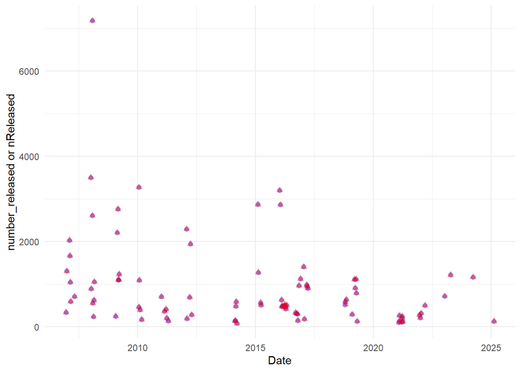

Random pick of data entry to compare between db and EDI

test 1

```
## Rows: 1
## Columns: 12
## $ id                          <int> 64024
## $ trap_location_id            <int> 54
## $ release_id                  <chr> "293"
## $ date_released               <dttm> 2017-03-15 09:00:17
## $ run_id                      <int> 3
## $ median_fork_length_released <dbl> NA
## $ lifestage_id                <int> 7
## $ origin_id                   <int> 2
## $ number_released             <dbl> 950
## $ updated_at                  <dttm> 2025-06-09 09:05:34
## $ updated_by                  <chr> "AdminJPE"
## $ stream                      <chr> "sacramento river"
```

```
## Rows: 1
## Columns: 16
## $ projectDescriptionID <dbl> 9
## $ releaseID            <dbl> 293
## $ releaseTime          <dttm> 2017-03-15 09:00:17
## $ commonName           <chr> "Chinook salmon"
## $ markedRun            <chr> "Fall"
## $ markedLifeStage      <chr> NA
## $ markedFishOrigin     <chr> "Hatchery"
## $ sourceOfFishSite     <chr> "Not yet assigned"
## $ releaseSite          <chr> "Knights Landing release site"
## $ releaseSubSite       <chr> NA
## $ nReleased            <dbl> 950
## $ testDays             <dbl> 45
## $ appliedMarkType      <chr> "Elastomer"
## $ appliedMarkColor     <chr> "Purple / Violet"
## $ appliedMarkPosition  <chr> "Nose"
## $ IncludeInAnalysis    <chr> "Yes"
```

test 2

```
## Rows: 1
## Columns: 12
## $ id                          <int> 63978
## $ trap_location_id            <int> 54
## $ release_id                  <chr> "577"
## $ date_released               <dttm> 2011-02-23 12:15:50
## $ run_id                      <int> 6
## $ median_fork_length_released <dbl> NA
## $ lifestage_id                <int> 7
## $ origin_id                   <int> 3
## $ number_released             <dbl> 370
## $ updated_at                  <dttm> 2025-06-09 09:05:34
## $ updated_by                  <chr> "AdminJPE"
## $ stream                      <chr> "sacramento river"
```

```
## Rows: 1
## Columns: 16
## $ projectDescriptionID <dbl> 9
## $ releaseID            <dbl> 577
## $ releaseTime          <dttm> 2011-02-23 12:15:50
## $ commonName           <chr> "Chinook salmon"
## $ markedRun            <chr> "Not recorded"
## $ markedLifeStage      <chr> NA
## $ markedFishOrigin     <chr> "Not recorded"
## $ sourceOfFishSite     <chr> "Knights Landing RST"
## $ releaseSite          <chr> "Knights Landing release site"
## $ releaseSubSite       <chr> NA
## $ nReleased            <dbl> 370
## $ testDays             <dbl> 7
## $ appliedMarkType      <chr> "Pigment / dye"
## $ appliedMarkColor     <chr> "Brown"
## $ appliedMarkPosition  <chr> "Whole body"
## $ IncludeInAnalysis    <chr> "Yes"
```

test 3

```
## Rows: 1
## Columns: 12
## $ id                          <int> 63991
## $ trap_location_id            <int> 54
## $ release_id                  <chr> "602"
## $ date_released               <dttm> 2021-04-01 10:30:08
## $ run_id                      <int> 3
## $ median_fork_length_released <dbl> NA
## $ lifestage_id                <int> 11
## $ origin_id                   <int> 2
## $ number_released             <dbl> 128
## $ updated_at                  <dttm> 2025-06-09 09:05:34
## $ updated_by                  <chr> "AdminJPE"
## $ stream                      <chr> "sacramento river"
```

```
## Rows: 1
## Columns: 16
## $ projectDescriptionID <dbl> 9
## $ releaseID            <dbl> 602
## $ releaseTime          <dttm> 2021-04-01 10:30:08
## $ commonName           <chr> "Chinook salmon"
## $ markedRun            <chr> "Fall"
## $ markedLifeStage      <chr> "Juvenile"
## $ markedFishOrigin     <chr> "Hatchery"
## $ sourceOfFishSite     <chr> "Knights Landing RST"
## $ releaseSite          <chr> "Knights Landing release site"
## $ releaseSubSite       <chr> NA
## $ nReleased            <dbl> 128
## $ testDays             <dbl> 10
## $ appliedMarkType      <chr> "Pigment / dye"
## $ appliedMarkColor     <chr> "Brown"
## $ appliedMarkPosition  <chr> "Whole body"
## $ IncludeInAnalysis    <chr> "Yes"
```

test 4

```
## Rows: 1
## Columns: 12
## $ id                          <int> 64008
## $ trap_location_id            <int> 54
## $ release_id                  <chr> "273"
## $ date_released               <dttm> 2016-02-10 10:20:17
## $ run_id                      <int> 3
## $ median_fork_length_released <dbl> NA
## $ lifestage_id                <int> 7
## $ origin_id                   <int> 2
## $ number_released             <dbl> 632
## $ updated_at                  <dttm> 2025-06-09 09:05:34
## $ updated_by                  <chr> "AdminJPE"
## $ stream                      <chr> "sacramento river"
```

```
## Rows: 1
## Columns: 16
## $ projectDescriptionID <dbl> 9
## $ releaseID            <dbl> 273
## $ releaseTime          <dttm> 2016-02-10 10:20:17
## $ commonName           <chr> "Chinook salmon"
## $ markedRun            <chr> "Fall"
## $ markedLifeStage      <chr> NA
## $ markedFishOrigin     <chr> "Hatchery"
## $ sourceOfFishSite     <chr> "Not yet assigned"
## $ releaseSite          <chr> "Knights Landing release site"
## $ releaseSubSite       <chr> NA
## $ nReleased            <dbl> 632
## $ testDays             <dbl> 62
## $ appliedMarkType      <chr> "Elastomer"
## $ appliedMarkColor     <chr> "Pink"
## $ appliedMarkPosition  <chr> "Nose"
## $ IncludeInAnalysis    <chr> "Yes"
```

#### recapture

**- Findings:** - EDI temporal coverage starts at earlier year than DB. Earliest year is 2007 - there are only 9 data entries on DB - DB lifestages are mostly just “5” and some “6”

- Database date range (`recaptured_fish`)

```
## [1] "2021-12-22" "2023-04-27"
```

column names DB

```
##  [1] "id"               "trap_location_id" "catch_raw_id"     "date"
##  [5] "count"            "run_id"           "lifestage_id"     "adipose_clipped"
##  [9] "dead"             "fork_length"      "weight"           "release_id"
## [13] "updated_at"       "stream"
```

column names EDI

```
##  [1] "ProjectDescriptionID" "catchRawID"           "trapVisitID"
##  [4] "commonName"           "releaseID"            "run"
##  [7] "fishOrigin"           "lifeStage"            "forkLength"
## [10] "n"                    "visitTime"            "visitTime2"
## [13] "visitType"            "siteName"             "subSiteName"
## [16] "markType"             "markColor"            "markPosition"
## [19] "markCode"             "trap_start_date"      "trap_end_date"
```

*date vs count/number_recapture*

- 0 % of values in the `count` column from the database are NA.
- 0 % of values in the `n` column from EDI are NA.

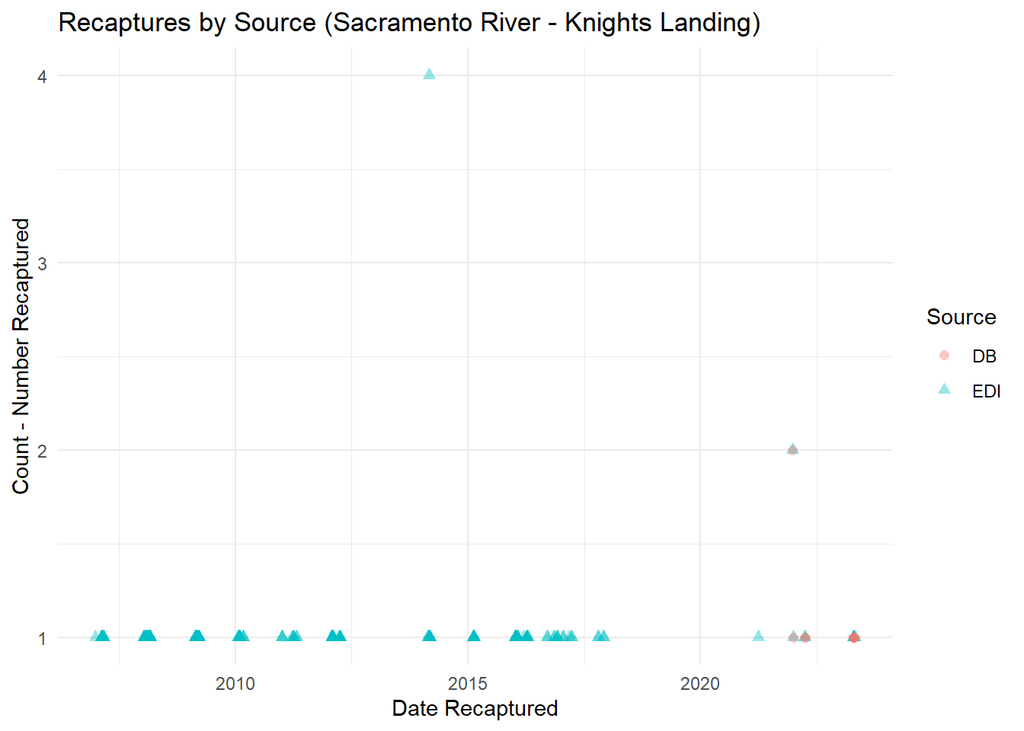

*fork_length*

- 22.2 % of values in the `fork_length` column from the database are NA.
- 1.5 % of values in the `forkLength` column from EDI are NA.

*lifestage*

- 0 % of values in the `lifestage_id` column from the database are NA.
- 0 % of values in the `lifeStage` column from EDI are NA.

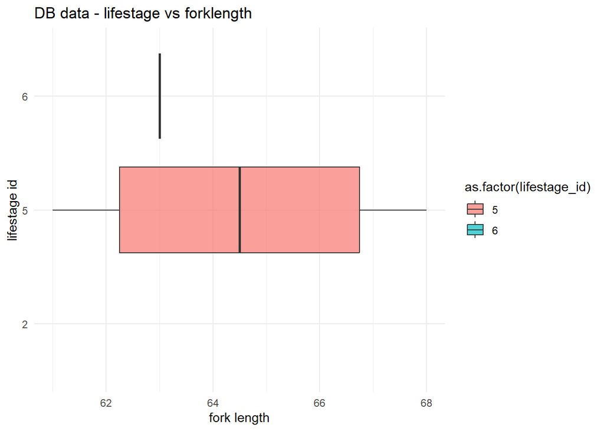

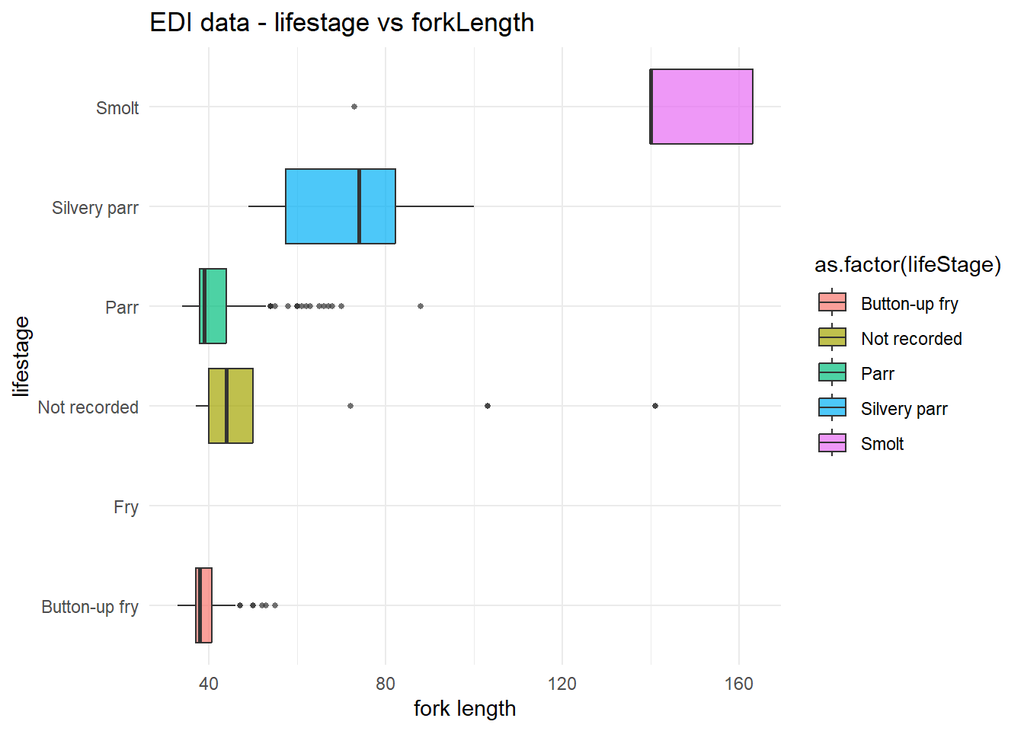

Random pick of data entry to compare between DB and EDI

- test 1

```
## Rows: 1
## Columns: 15
## $ id               <int> 248535
## $ trap_location_id <int> 51
## $ catch_raw_id     <int> 160190
## $ date             <date> 2023-04-14
## $ count            <dbl> 1
## $ run_id           <int> 3
## $ lifestage_id     <int> 5
## $ adipose_clipped  <lgl> FALSE
## $ dead             <lgl> TRUE
## $ fork_length      <dbl> 63
## $ weight           <dbl> NA
## $ release_id       <chr> "616"
## $ updated_at       <dttm> 2025-06-09 09:05:33
## $ stream           <chr> "sacramento river"
## $ source           <chr> "DB"
```

```
## Rows: 1
## Columns: 24
## $ ProjectDescriptionID <dbl> 9
## $ catchRawID           <dbl> 160190
## $ trapVisitID          <dbl> 7679
## $ commonName           <chr> "Chinook salmon"
## $ releaseID            <dbl> 616
## $ run                  <chr> "Fall"
## $ fishOrigin           <chr> "Natural"
## $ lifeStage            <chr> "Parr"
## $ forkLength           <dbl> 63
## $ n                    <dbl> 1
## $ visitTime            <dttm> 2023-04-14 09:45:32
## $ visitTime2           <dttm> 2023-04-14 09:45:32
## $ visitType            <chr> "Unplanned restart"
## $ siteName             <chr> "Knights Landing RST"
## $ subSiteName          <dbl> 8.3
## $ markType             <chr> "Pigment / dye"
## $ markColor            <chr> "Brown"
## $ markPosition         <chr> "Whole body"
## $ markCode             <lgl> NA
## $ trap_start_date      <dttm> 2023-04-13 10:45:12
## $ trap_end_date        <dttm> 2023-04-14 09:45:32
## $ source               <chr> "EDI"
## $ date                 <date> 2023-04-14
## $ count                <dbl> 1
```

- test 2

```
## Rows: 1
## Columns: 15
## $ id               <int> 248539
## $ trap_location_id <int> 52
## $ catch_raw_id     <int> 160506
## $ date             <date> 2023-04-27
## $ count            <dbl> 1
## $ run_id           <int> 3
## $ lifestage_id     <int> 5
## $ adipose_clipped  <lgl> FALSE
## $ dead             <lgl> TRUE
## $ fork_length      <dbl> 66
## $ weight           <dbl> NA
## $ release_id       <chr> "614"
## $ updated_at       <dttm> 2025-06-09 09:05:33
## $ stream           <chr> "sacramento river"
## $ source           <chr> "DB"
```

```
## Rows: 1
## Columns: 24
## $ ProjectDescriptionID <dbl> 9
## $ catchRawID           <dbl> 160506
## $ trapVisitID          <dbl> 7706
## $ commonName           <chr> "Chinook salmon"
## $ releaseID            <dbl> 614
## $ run                  <chr> "Fall"
## $ fishOrigin           <chr> "Natural"
## $ lifeStage            <chr> "Parr"
## $ forkLength           <dbl> 66
## $ n                    <dbl> 1
## $ visitTime            <dttm> 2023-04-27 10:45:43
## $ visitTime2           <dttm> 2023-04-27 10:45:43
## $ visitType            <chr> "Unplanned restart"
## $ siteName             <chr> "Knights Landing RST"
## $ subSiteName          <dbl> 8.4
## $ markType             <chr> "Pigment / dye"
## $ markColor            <chr> "Brown"
## $ markPosition         <chr> "Whole body"
## $ markCode             <lgl> NA
## $ trap_start_date      <dttm> 2023-04-26 11:00:18
## $ trap_end_date        <dttm> 2023-04-27 10:45:43
## $ source               <chr> "EDI"
## $ date                 <date> 2023-04-27
## $ count                <dbl> 1
```

- test 3

```
## Rows: 1
## Columns: 15
## $ id               <int> 248531
## $ trap_location_id <int> 51
## $ catch_raw_id     <int> 152127
## $ date             <date> 2022-03-26
## $ count            <dbl> 1
## $ run_id           <int> 3
## $ lifestage_id     <int> 6
## $ adipose_clipped  <lgl> FALSE
## $ dead             <lgl> TRUE
## $ fork_length      <dbl> 63
## $ weight           <dbl> NA
## $ release_id       <chr> "605"
## $ updated_at       <dttm> 2025-06-09 09:05:33
## $ stream           <chr> "sacramento river"
## $ source           <chr> "DB"
```

```
## Rows: 1
## Columns: 24
## $ ProjectDescriptionID <dbl> 9
## $ catchRawID           <dbl> 152127
## $ trapVisitID          <dbl> 7182
## $ commonName           <chr> "Chinook salmon"
## $ releaseID            <dbl> 605
## $ run                  <chr> "Fall"
## $ fishOrigin           <chr> "Not recorded"
## $ lifeStage            <chr> "Silvery parr"
## $ forkLength           <dbl> 63
## $ n                    <dbl> 1
## $ visitTime            <dttm> 2022-03-26 09:45:44
## $ visitTime2           <dttm> 2022-03-26 09:45:44
## $ visitType            <chr> "Continue trapping"
## $ siteName             <chr> "Knights Landing RST"
## $ subSiteName          <dbl> 8.3
## $ markType             <chr> "Elastomer"
## $ markColor            <chr> "Pink"
## $ markPosition         <chr> "Nose"
## $ markCode             <lgl> NA
## $ trap_start_date      <dttm> 2022-03-25 10:00:12
## $ trap_end_date        <dttm> 2022-03-26 09:45:44
## $ source               <chr> "EDI"
## $ date                 <date> 2022-03-26
## $ count                <dbl> 1
```

- test 4

```
## Rows: 1
## Columns: 15
## $ id               <int> 248533
## $ trap_location_id <int> 51
## $ catch_raw_id     <int> 152129
## $ date             <date> 2021-12-22
## $ count            <dbl> 2
## $ run_id           <int> 5
## $ lifestage_id     <int> 2
## $ adipose_clipped  <lgl> FALSE
## $ dead             <lgl> TRUE
## $ fork_length      <dbl> NA
## $ weight           <dbl> NA
## $ release_id       <chr> "608"
## $ updated_at       <dttm> 2025-06-09 09:05:33
## $ stream           <chr> "sacramento river"
## $ source           <chr> "DB"
```

```
## Rows: 1
## Columns: 24
## $ ProjectDescriptionID <dbl> 9
## $ catchRawID           <dbl> 152129
## $ trapVisitID          <dbl> 7034
## $ commonName           <chr> "Chinook salmon"
## $ releaseID            <dbl> 608
## $ run                  <chr> NA
## $ fishOrigin           <chr> "Natural"
## $ lifeStage            <chr> "Fry"
## $ forkLength           <dbl> NA
## $ n                    <dbl> 2
## $ visitTime            <dttm> 2021-12-22 10:00:00
## $ visitTime2           <dttm> 2021-12-22 10:00:00
## $ visitType            <chr> "Continue trapping"
## $ siteName             <chr> "Knights Landing RST"
## $ subSiteName          <dbl> 8.3
## $ markType             <chr> "Pigment / dye"
## $ markColor            <chr> "Not recorded"
## $ markPosition         <chr> "Whole body"
## $ markCode             <lgl> NA
## $ trap_start_date      <dttm> 2021-12-21 11:30:36
## $ trap_end_date        <dttm> 2021-12-22 10:00:00
## $ source               <chr> "EDI"
## $ date                 <date> 2021-12-22
## $ count                <dbl> 2
```

### Sacramento/Tisdale

#### catch

**- Findings:** - Date range is different (edi’s earliest year us 2010) - there is an outline fork length value on EDI in 2020 - lifestage has more categories in EDI data

- Database date range

```
## [1] "2022-09-19" "2024-09-04"
```

- EDI date range

```
## [1] "2010-07-06 13:00:34 UTC" "2024-09-04 10:00:57 UTC"
```

*fork_length*

EDI

- 24.7 % of values in the `forkLength` column are NA.

```
##    Min. 1st Qu.  Median    Mean 3rd Qu.    Max.    NA's
##    0.00   38.00   44.00   57.51   75.00 4038.00   21274
```

DB

- 6.3 % of values in the `fork_length` column are NA.

```
##    Min. 1st Qu.  Median    Mean 3rd Qu.    Max.    NA's
##   26.00   38.00   41.00   54.07   74.00  250.00     514
```

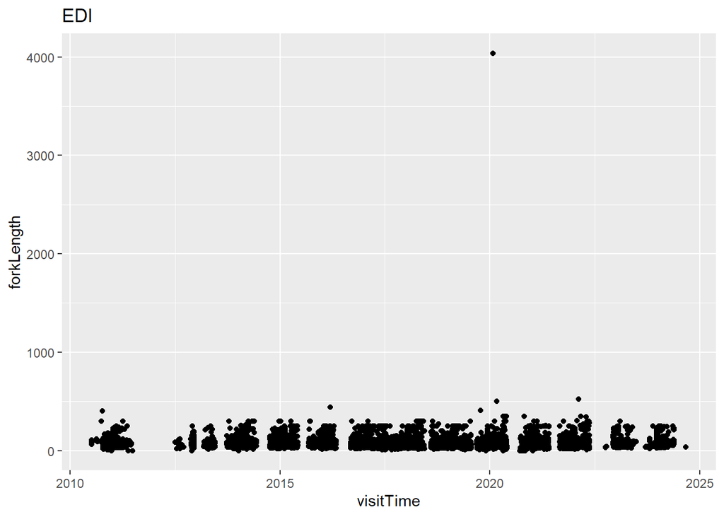

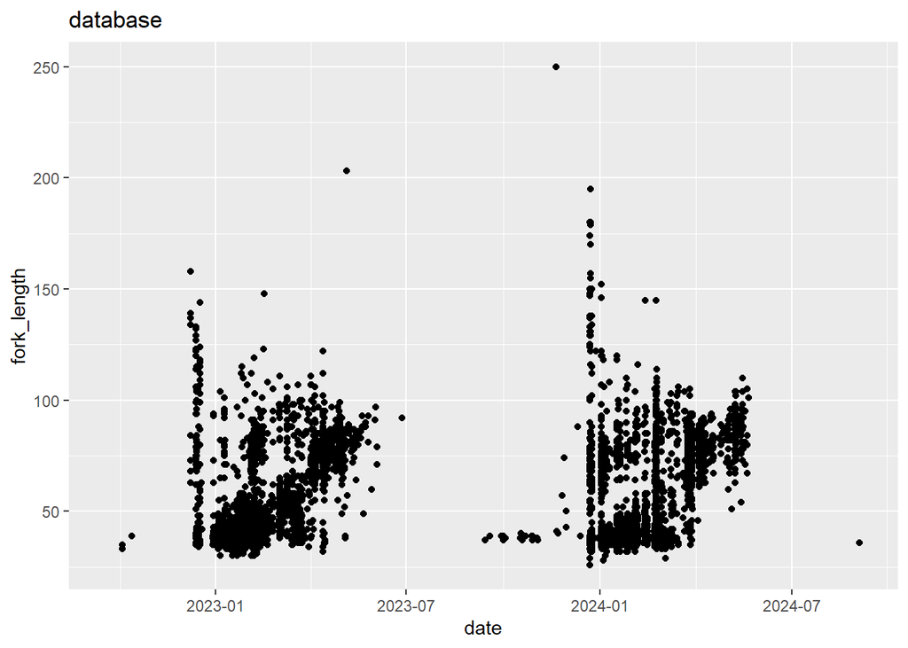

filtering only matching years (2022 onwards)

exploration plots

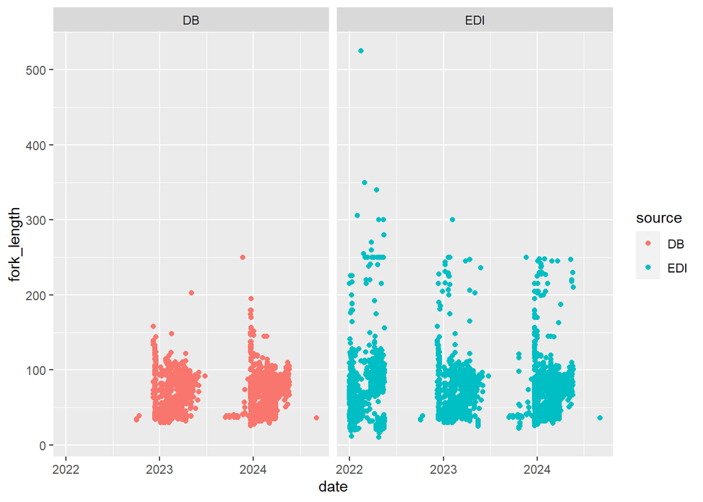

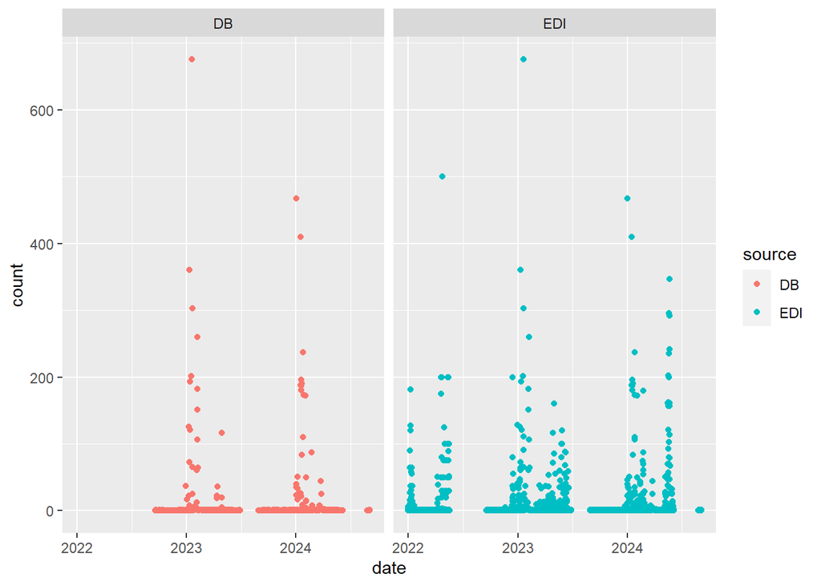

- 0 % of values in the `lifestage_id` column from the database are NA.

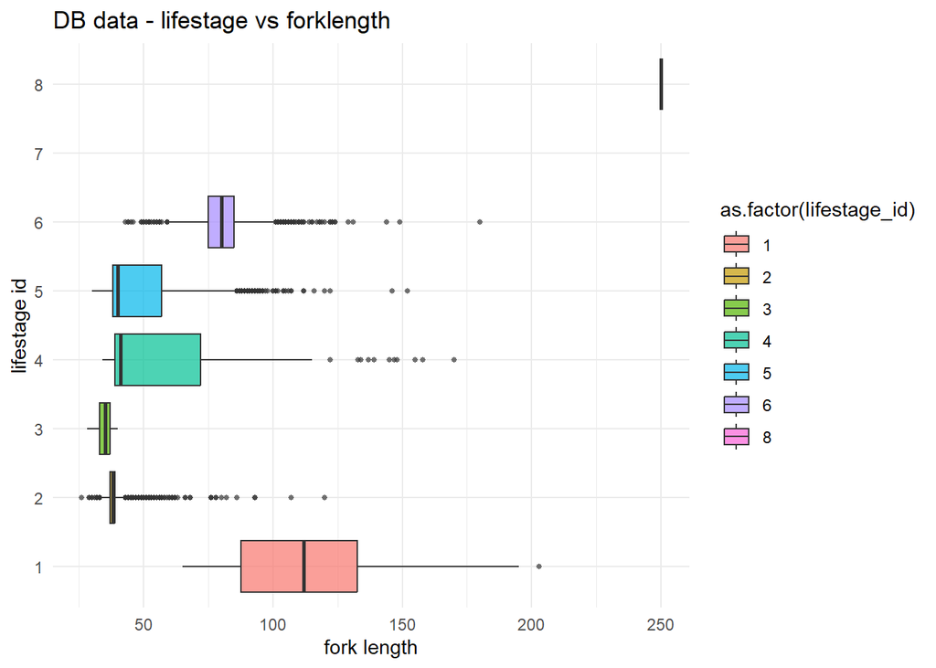

- 0 % of values in the `lifeStage` column from EDI are NA.

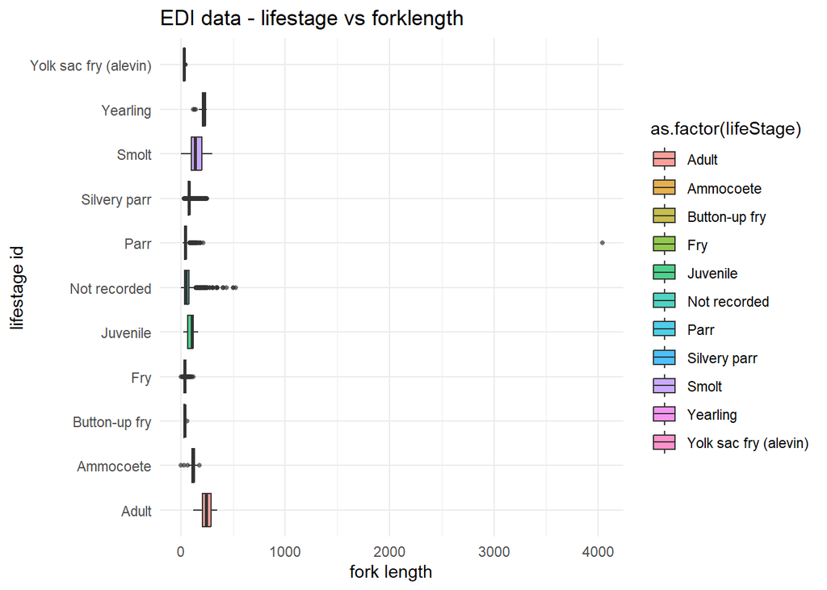

Random pick of data entry to compare between db and EDI

test 1

```
## Rows: 1
## Columns: 14
## $ id               <int> 45961356
## $ catch_raw_id     <chr> "73027"
## $ trap_location_id <int> 56
## $ date             <date> 2022-10-06
## $ count            <dbl> 0
## $ run_id           <int> 6
## $ lifestage_id     <int> 7
## $ adipose_clipped  <lgl> FALSE
## $ dead             <lgl> TRUE
## $ fork_length      <dbl> NA
## $ weight           <dbl> NA
## $ actual_count     <lgl> TRUE
## $ updated_at       <dttm> 2025-06-09 09:05:44
## $ stream           <chr> "sacramento river"
```

```
## Rows: 1
## Columns: 20
## $ ProjectDescriptionID <dbl> 10
## $ catchRawID           <dbl> 73027
## $ trapVisitID          <dbl> 6620
## $ commonName           <chr> "Chinook salmon"
## $ releaseID            <dbl> 0
## $ atCaptureRun         <chr> "Not recorded"
## $ fishOrigin           <chr> "Natural"
## $ lifeStage            <chr> "Not recorded"
## $ forkLength           <dbl> NA
## $ totalLength          <dbl> NA
## $ n                    <dbl> 0
## $ visitTime            <dttm> 2022-10-06 09:45:16
## $ visitTime2           <dttm> 2022-10-06 09:45:16
## $ visitType            <chr> "Continue trapping"
## $ siteName             <chr> "Tisdale Weir RST"
## $ subSiteName          <chr> "RL"
## $ finalRun             <chr> NA
## $ actualCount          <chr> "Yes"
## $ trap_start_date      <dttm> 2022-10-05 10:15:35
## $ trap_end_date        <dttm> 2022-10-06 09:45:16
```

test 2

```
## Rows: 1
## Columns: 14
## $ id               <int> 45966963
## $ catch_raw_id     <chr> "79378"
## $ trap_location_id <int> 55
## $ date             <date> 2023-04-28
## $ count            <dbl> 5
## $ run_id           <int> 3
## $ lifestage_id     <int> 4
## $ adipose_clipped  <lgl> FALSE
## $ dead             <lgl> TRUE
## $ fork_length      <dbl> NA
## $ weight           <dbl> NA
## $ actual_count     <lgl> TRUE
## $ updated_at       <dttm> 2025-06-09 09:05:44
## $ stream           <chr> "sacramento river"
```

```
## Rows: 1
## Columns: 20
## $ ProjectDescriptionID <dbl> 10
## $ catchRawID           <dbl> 79378
## $ trapVisitID          <dbl> 7010
## $ commonName           <chr> "Chinook salmon"
## $ releaseID            <dbl> 0
## $ atCaptureRun         <chr> "Fall"
## $ fishOrigin           <chr> "Natural"
## $ lifeStage            <chr> "Not recorded"
## $ forkLength           <dbl> NA
## $ totalLength          <dbl> NA
## $ n                    <dbl> 5
## $ visitTime            <dttm> 2023-04-28 10:00:08
## $ visitTime2           <dttm> 2023-04-28 10:00:08
## $ visitType            <chr> "Continue trapping"
## $ siteName             <chr> "Tisdale Weir RST"
## $ subSiteName          <chr> "RR"
## $ finalRun             <chr> NA
## $ actualCount          <chr> "Yes"
## $ trap_start_date      <dttm> 2023-04-28 10:00:08
## $ trap_end_date        <dttm> 2023-04-28 10:00:08
```

test 3

```
## Rows: 1
## Columns: 14
## $ id               <int> 45967250
## $ catch_raw_id     <chr> "81039"
## $ trap_location_id <int> 55
## $ date             <date> 2023-10-10
## $ count            <dbl> 0
## $ run_id           <int> 6
## $ lifestage_id     <int> 7
## $ adipose_clipped  <lgl> FALSE
## $ dead             <lgl> TRUE
## $ fork_length      <dbl> NA
## $ weight           <dbl> NA
## $ actual_count     <lgl> TRUE
## $ updated_at       <dttm> 2025-06-09 09:05:44
## $ stream           <chr> "sacramento river"
```

```
## Rows: 1
## Columns: 20
## $ ProjectDescriptionID <dbl> 10
## $ catchRawID           <dbl> 81039
## $ trapVisitID          <dbl> 7228
## $ commonName           <chr> "Chinook salmon"
## $ releaseID            <dbl> 0
## $ atCaptureRun         <chr> "Not recorded"
## $ fishOrigin           <chr> "Natural"
## $ lifeStage            <chr> "Not recorded"
## $ forkLength           <dbl> NA
## $ totalLength          <dbl> NA
## $ n                    <dbl> 0
## $ visitTime            <dttm> 2023-10-10 10:30:48
## $ visitTime2           <dttm> 2023-10-10 10:30:48
## $ visitType            <chr> "Unplanned restart"
## $ siteName             <chr> "Tisdale Weir RST"
## $ subSiteName          <chr> "RR"
## $ finalRun             <chr> NA
## $ actualCount          <chr> "Yes"
## $ trap_start_date      <dttm> 2023-10-09 11:15:11
## $ trap_end_date        <dttm> 2023-10-10 10:30:48
```

test 4

```
## Rows: 1
## Columns: 14
## $ id               <int> 45968193
## $ catch_raw_id     <chr> "83735"
## $ trap_location_id <int> 55
## $ date             <date> 2024-01-25
## $ count            <dbl> 0
## $ run_id           <int> 6
## $ lifestage_id     <int> 7
## $ adipose_clipped  <lgl> FALSE
## $ dead             <lgl> TRUE
## $ fork_length      <dbl> NA
## $ weight           <dbl> NA
## $ actual_count     <lgl> TRUE
## $ updated_at       <dttm> 2025-06-09 09:05:44
## $ stream           <chr> "sacramento river"
```

```
## Rows: 1
## Columns: 20
## $ ProjectDescriptionID <dbl> 10
## $ catchRawID           <dbl> 83735
## $ trapVisitID          <dbl> 7433
## $ commonName           <chr> "Chinook salmon"
## $ releaseID            <dbl> 0
## $ atCaptureRun         <chr> "Not recorded"
## $ fishOrigin           <chr> "Natural"
## $ lifeStage            <chr> "Not recorded"
## $ forkLength           <dbl> NA
## $ totalLength          <dbl> NA
## $ n                    <dbl> 0
## $ visitTime            <dttm> 2024-01-25 12:00:03
## $ visitTime2           <dttm> 2024-01-25 12:00:03
## $ visitType            <chr> "Start trap & begin trapping"
## $ siteName             <chr> "Tisdale Weir RST"
## $ subSiteName          <chr> "RR"
## $ finalRun             <chr> NA
## $ actualCount          <chr> "Yes"
## $ trap_start_date      <dttm> 2024-01-25 12:00:03
## $ trap_end_date        <dttm> 2024-01-25 12:00:03
```

#### trap

Column names DB

```
##  [1] "id"                         "trap_location_id"
##  [3] "trap_visit_id"              "visit_type_id"
##  [5] "trap_visit_time_start"      "trap_visit_time_end"
##  [7] "trap_functioning_id"        "in_half_cone_configuration"
##  [9] "fish_processed_id"          "rpm_start"
## [11] "rpm_end"                    "total_revolutions"
## [13] "debris_volume"              "debris_level_id"
## [15] "discharge"                  "water_velocity"
## [17] "water_temp"                 "turbidity"
## [19] "include"                    "updated_at"
## [21] "updated_by"                 "stream"
```

- Database date range

`trap_visit_time_start`

```
## [1] "2022-09-19 10:30:00 UTC" "2024-10-09 10:00:46 UTC"
```

`trap_visit_time_end`

```
## [1] "2022-09-19 10:30:00 UTC" "2024-10-09 10:00:56 UTC"
```

- EDI date range (`visitTime`)

```
## [1] "2010-07-06 13:00:34 UTC" "2024-10-09 10:00:56 UTC"
```

Column names EDI

```
##  [1] "projectDescriptionID"  "trapVisitID"           "siteName"
##  [4] "subSiteName"           "visitTime"             "visitTime2"
##  [7] "visitType"             "fishProcessed"         "trapFunctioning"
## [10] "counterAtStart"        "counterAtEnd"          "rpmRevolutionsAtStart"
## [13] "rpmRevolutionsAtEnd"   "includeCatch"          "discharge"
## [16] "waterVel"              "waterTemp"             "lightPenetration"
## [19] "turbidity"             "dissolvedOxygen"       "conductivity"
## [22] "trap_start_date"       "trap_end_date"
```

*water_temp*

DB

- 1.1 % of values in the `water_temp` column in the database dataset are NA.

```
##    Min. 1st Qu.  Median    Mean 3rd Qu.    Max.    NA's
##    1.70   10.03   13.20   13.81   18.00   21.50      13
```

EDI

- 3.1 % of values in the `waterTemp` column in the EDI dataset are NA.

```
##    Min. 1st Qu.  Median    Mean 3rd Qu.    Max.    NA's
##    1.70   10.00   13.00   13.50   16.83   24.44     229
```

*turbidity*

DB * 1.1 % of values in the `turbidity` column in the database dataset are NA.

```
##     Min.  1st Qu.   Median     Mean  3rd Qu.     Max.     NA's
##    1.340    5.085   11.450   31.696   23.320 2079.000       13
```

EDI * 4.1 % of values in the `turbidity` column in EDI dataset are NA.

```
##     Min.  1st Qu.   Median     Mean  3rd Qu.     Max.     NA's
##    0.970    6.215   11.650   26.960   20.600 2079.000      305
```

test 1

```
## Rows: 1
## Columns: 22
## $ id                         <int> 2069220
## $ trap_location_id           <int> 56
## $ trap_visit_id              <chr> "6675"
## $ visit_type_id              <int> 5
## $ trap_visit_time_start      <dttm> 2022-10-31 10:15:33
## $ trap_visit_time_end        <dttm> 2022-11-01 10:30:49
## $ trap_functioning_id        <int> NA
## $ in_half_cone_configuration <lgl> TRUE
## $ fish_processed_id          <int> 3
## $ rpm_start                  <dbl> 0
## $ rpm_end                    <dbl> 2.4
## $ total_revolutions          <dbl> NA
## $ debris_volume              <dbl> NA
## $ debris_level_id            <int> NA
## $ discharge                  <dbl> 3466
## $ water_velocity             <dbl> NA
## $ water_temp                 <dbl> 14
## $ turbidity                  <dbl> 2.26
## $ include                    <lgl> TRUE
## $ updated_at                 <dttm> 2025-06-09 09:05:52
## $ updated_by                 <chr> "AdminJPE"
## $ stream                     <chr> "sacramento river"
```

```
## Rows: 1
## Columns: 23
## $ projectDescriptionID  <dbl> 10
## $ trapVisitID           <dbl> 6675
## $ siteName              <chr> "Tisdale Weir RST"
## $ subSiteName           <chr> "RL"
## $ visitTime             <dttm> 2022-11-01 10:30:49
## $ visitTime2            <dttm> 2022-11-01 10:30:49
## $ visitType             <chr> "Unplanned restart"
## $ fishProcessed         <chr> "No fish were caught"
## $ trapFunctioning       <chr> "Trap stopped functioning"
## $ counterAtStart        <dbl> 597
## $ counterAtEnd          <dbl> NA
## $ rpmRevolutionsAtStart <dbl> 0
## $ rpmRevolutionsAtEnd   <dbl> 2.4
## $ includeCatch          <chr> "Yes"
## $ discharge             <dbl> 3466
## $ waterVel              <dbl> 0.55
## $ waterTemp             <dbl> 14
## $ lightPenetration      <dbl> NA
## $ turbidity             <dbl> 2.26
## $ dissolvedOxygen       <dbl> 10.09
## $ conductivity          <dbl> 157
## $ trap_start_date       <dttm> 2022-10-31 10:15:33
## $ trap_end_date         <dttm> 2022-11-01 10:30:49
```

test 2

```
## Rows: 1
## Columns: 22
## $ id                         <int> 2069463
## $ trap_location_id           <int> 56
## $ trap_visit_id              <chr> "7175"
## $ visit_type_id              <int> 2
## $ trap_visit_time_start      <dttm> 2023-09-13 10:15:00
## $ trap_visit_time_end        <dttm> 2023-09-14 10:00:07
## $ trap_functioning_id        <int> NA
## $ in_half_cone_configuration <lgl> TRUE
## $ fish_processed_id          <int> 3
## $ rpm_start                  <dbl> 1.95
## $ rpm_end                    <dbl> 1.45
## $ total_revolutions          <dbl> 2831
## $ debris_volume              <dbl> NA
## $ debris_level_id            <int> NA
## $ discharge                  <dbl> 6708
## $ water_velocity             <dbl> NA
## $ water_temp                 <dbl> 19.2
## $ turbidity                  <dbl> 5.38
## $ include                    <lgl> TRUE
## $ updated_at                 <dttm> 2025-06-09 09:05:52
## $ updated_by                 <chr> "AdminJPE"
## $ stream                     <chr> "sacramento river"
```

```
## Rows: 1
## Columns: 23
## $ projectDescriptionID  <dbl> 10
## $ trapVisitID           <dbl> 7175
## $ siteName              <chr> "Tisdale Weir RST"
## $ subSiteName           <chr> "RL"
## $ visitTime             <dttm> 2023-09-14 10:00:07
## $ visitTime2            <dttm> 2023-09-14 10:00:07
## $ visitType             <chr> "Continue trapping"
## $ fishProcessed         <chr> "No fish were caught"
## $ trapFunctioning       <chr> "Trap functioning normally"
## $ counterAtStart        <dbl> NA
## $ counterAtEnd          <dbl> 2831
## $ rpmRevolutionsAtStart <dbl> 1.95
## $ rpmRevolutionsAtEnd   <dbl> 1.45
## $ includeCatch          <chr> "Yes"
## $ discharge             <dbl> 6708
## $ waterVel              <dbl> 0.5
## $ waterTemp             <dbl> 19.2
## $ lightPenetration      <dbl> NA
## $ turbidity             <dbl> 5.38
## $ dissolvedOxygen       <dbl> 9.06
## $ conductivity          <dbl> 144.6
## $ trap_start_date       <dttm> 2023-09-13 10:15:00
## $ trap_end_date         <dttm> 2023-09-14 10:00:07
```

test 3

```
## Rows: 1
## Columns: 22
## $ id                         <int> 2069899
## $ trap_location_id           <int> 55
## $ trap_visit_id              <chr> "7409"
## $ visit_type_id              <int> 5
## $ trap_visit_time_start      <dttm> 2023-02-15 09:45:46
## $ trap_visit_time_end        <dttm> 2023-02-16 09:45:08
## $ trap_functioning_id        <int> NA
## $ in_half_cone_configuration <lgl> TRUE
## $ fish_processed_id          <int> 2
## $ rpm_start                  <dbl> 0
## $ rpm_end                    <dbl> 3.25
## $ total_revolutions          <dbl> NA
## $ debris_volume              <dbl> NA
## $ debris_level_id            <int> NA
## $ discharge                  <dbl> 8421
## $ water_velocity             <dbl> NA
## $ water_temp                 <dbl> 8.944444
## $ turbidity                  <dbl> 14.96
## $ include                    <lgl> TRUE
## $ updated_at                 <dttm> 2025-06-09 09:05:52
## $ updated_by                 <chr> "AdminJPE"
## $ stream                     <chr> "sacramento river"
```

```
## Rows: 1
## Columns: 23
## $ projectDescriptionID  <dbl> 10
## $ trapVisitID           <dbl> 7409
## $ siteName              <chr> "Tisdale Weir RST"
## $ subSiteName           <chr> "RR"
## $ visitTime             <dttm> 2023-02-16 09:45:08
## $ visitTime2            <dttm> 2023-02-16 09:45:08
## $ visitType             <chr> "Unplanned restart"
## $ fishProcessed         <chr> "Processed fish"
## $ trapFunctioning       <chr> "Trap stopped functioning"
## $ counterAtStart        <dbl> 2674
## $ counterAtEnd          <dbl> NA
## $ rpmRevolutionsAtStart <dbl> 0
## $ rpmRevolutionsAtEnd   <dbl> 3.25
## $ includeCatch          <chr> "Yes"
## $ discharge             <dbl> 8421
## $ waterVel              <dbl> 0.6
## $ waterTemp             <dbl> 8.944444
## $ lightPenetration      <dbl> NA
## $ turbidity             <dbl> 14.96
## $ dissolvedOxygen       <dbl> 11.02
## $ conductivity          <dbl> 205.4
## $ trap_start_date       <dttm> 2023-02-15 09:45:46
## $ trap_end_date         <dttm> 2023-02-16 09:45:08
```

test 4

```
## Rows: 1
## Columns: 22
## $ id                         <int> 2070318
## $ trap_location_id           <int> 55
## $ trap_visit_id              <chr> "7735"
## $ visit_type_id              <int> 5
## $ trap_visit_time_start      <dttm> 2024-09-25 00:00:56
## $ trap_visit_time_end        <dttm> 2024-09-26 11:00:46
## $ trap_functioning_id        <int> NA
## $ in_half_cone_configuration <lgl> TRUE
## $ fish_processed_id          <int> 2
## $ rpm_start                  <dbl> 0
## $ rpm_end                    <dbl> 2.75
## $ total_revolutions          <dbl> 581
## $ debris_volume              <dbl> NA
## $ debris_level_id            <int> NA
## $ discharge                  <dbl> 6758
## $ water_velocity             <dbl> NA
## $ water_temp                 <dbl> 18.2
## $ turbidity                  <dbl> 4.78
## $ include                    <lgl> TRUE
## $ updated_at                 <dttm> 2025-06-09 09:05:52
## $ updated_by                 <chr> "AdminJPE"
## $ stream                     <chr> "sacramento river"
```

```
## Rows: 1
## Columns: 23
## $ projectDescriptionID  <dbl> 10
## $ trapVisitID           <dbl> 7735
## $ siteName              <chr> "Tisdale Weir RST"
## $ subSiteName           <chr> "RR"
## $ visitTime             <dttm> 2024-09-26 11:00:46
## $ visitTime2            <dttm> 2024-09-26 11:00:46
## $ visitType             <chr> "Unplanned restart"
## $ fishProcessed         <chr> "Processed fish"
## $ trapFunctioning       <chr> "Trap stopped functioning"
## $ counterAtStart        <dbl> 581
## $ counterAtEnd          <dbl> 581
## $ rpmRevolutionsAtStart <dbl> 0
## $ rpmRevolutionsAtEnd   <dbl> 2.75
## $ includeCatch          <chr> "Yes"
## $ discharge             <dbl> 6758
## $ waterVel              <dbl> NA
## $ waterTemp             <dbl> 18.2
## $ lightPenetration      <dbl> NA
## $ turbidity             <dbl> 4.78
## $ dissolvedOxygen       <dbl> 8.98
## $ conductivity          <dbl> 139
## $ trap_start_date       <dttm> 2024-09-25 00:00:56
## $ trap_end_date         <dttm> 2024-09-26 11:00:46
```

#### release

- Database date range

```
## [1] "2012-02-05 12:00:32 UTC" "2024-03-28 12:00:08 UTC"
```

column names

```
##  [1] "id"                          "trap_location_id"
##  [3] "release_id"                  "date_released"
##  [5] "run_id"                      "median_fork_length_released"
##  [7] "lifestage_id"                "origin_id"
##  [9] "number_released"             "updated_at"
## [11] "updated_by"                  "stream"
```

- EDI date range (`releaseTime`)

```
## [1] "2012-02-05 12:00:32 UTC" "2024-03-28 12:00:08 UTC"
```

column names

```
##  [1] "projectDescriptionID" "releaseID"            "commonName"
##  [4] "markedRun"            "markedLifeStage"      "markedFishOrigin"
##  [7] "sourceOfFishSite"     "releaseSite"          "releaseSubSite"
## [10] "nReleased"            "releaseTime"          "testDays"
## [13] "appliedMarkType"      "appliedMarkColor"     "appliedMarkPosition"
## [16] "appliedMarkCode"      "includeAnalysis"
```

*number_released or nReleased*

DB * 0 % of values in the `number_released` column in the database dataset are NA.

```
##    Min. 1st Qu.  Median    Mean 3rd Qu.    Max.
##    92.0   413.8   501.0   669.8  1028.8  1941.0
```

EDI * 0 % of values in the `nReleased` column in EDI dataset are NA.

```
##    Min. 1st Qu.  Median    Mean 3rd Qu.    Max.
##    75.0   340.0   500.0   609.3   995.0  1941.0
```

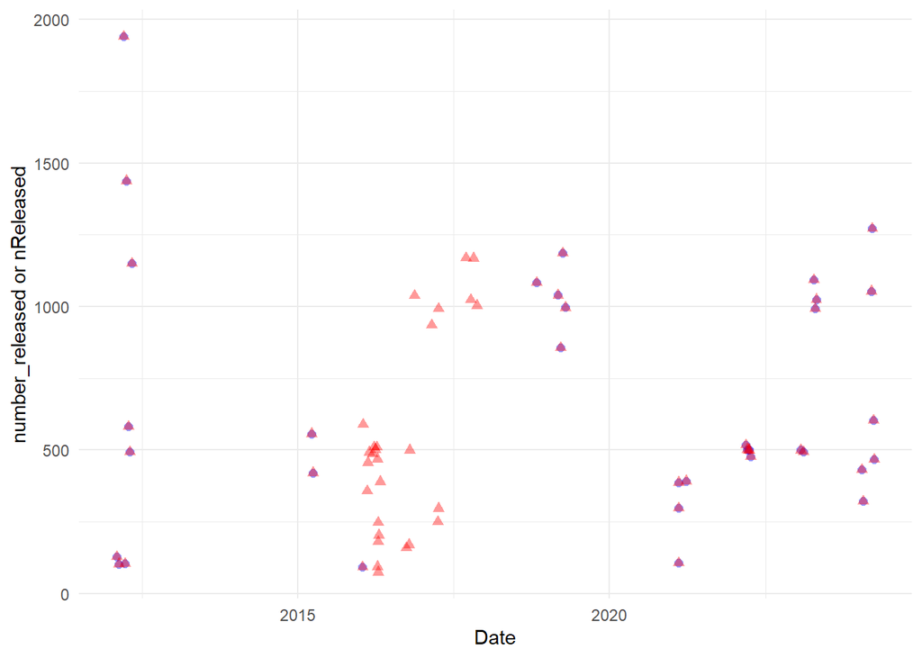

Random pick of data entry to compare between db and EDI

test 1

```
## Rows: 1
## Columns: 12
## $ id                          <int> 64067
## $ trap_location_id            <int> 57
## $ release_id                  <chr> "303"
## $ date_released               <dttm> 2019-03-06 12:00:08
## $ run_id                      <int> 3
## $ median_fork_length_released <dbl> NA
## $ lifestage_id                <int> 7
## $ origin_id                   <int> 2
## $ number_released             <dbl> 1040
## $ updated_at                  <dttm> 2025-06-09 09:05:51
## $ updated_by                  <chr> "AdminJPE"
## $ stream                      <chr> "sacramento river"
```

```
## Rows: 1
## Columns: 17
## $ projectDescriptionID <dbl> 10
## $ releaseID            <dbl> 303
## $ commonName           <chr> "Chinook salmon"
## $ markedRun            <chr> "Fall"
## $ markedLifeStage      <chr> NA
## $ markedFishOrigin     <chr> "Hatchery"
## $ sourceOfFishSite     <chr> NA
## $ releaseSite          <chr> "Tisdale Weir release site"
## $ releaseSubSite       <chr> NA
## $ nReleased            <dbl> 1040
## $ releaseTime          <dttm> 2019-03-06 12:00:08
## $ testDays             <dbl> 7
## $ appliedMarkType      <chr> "Elastomer"
## $ appliedMarkColor     <chr> "Orange"
## $ appliedMarkPosition  <chr> "Nose"
## $ appliedMarkCode      <lgl> NA
## $ includeAnalysis      <chr> "Yes"
```

test 2

```
## Rows: 1
## Columns: 12
## $ id                          <int> 64058
## $ trap_location_id            <int> 57
## $ release_id                  <chr> "294"
## $ date_released               <dttm> 2012-03-25 12:00:32
## $ run_id                      <int> 3
## $ median_fork_length_released <dbl> NA
## $ lifestage_id                <int> 7
## $ origin_id                   <int> 2
## $ number_released             <dbl> 104
## $ updated_at                  <dttm> 2025-06-09 09:05:51
## $ updated_by                  <chr> "AdminJPE"
## $ stream                      <chr> "sacramento river"
```

```
## Rows: 1
## Columns: 17
## $ projectDescriptionID <dbl> 10
## $ releaseID            <dbl> 294
## $ commonName           <chr> "Chinook salmon"
## $ markedRun            <chr> "Fall"
## $ markedLifeStage      <chr> NA
## $ markedFishOrigin     <chr> "Hatchery"
## $ sourceOfFishSite     <chr> NA
## $ releaseSite          <chr> "Tisdale Weir release site"
## $ releaseSubSite       <chr> NA
## $ nReleased            <dbl> 104
## $ releaseTime          <dttm> 2012-03-25 12:00:32
## $ testDays             <dbl> 7
## $ appliedMarkType      <chr> "Pigment / dye"
## $ appliedMarkColor     <chr> "Not applicable (n/a)"
## $ appliedMarkPosition  <chr> "Not applicable (n/a)"
## $ appliedMarkCode      <lgl> NA
## $ includeAnalysis      <chr> "Yes"
```

test 3

```
## Rows: 1
## Columns: 12
## $ id                          <int> 64060
## $ trap_location_id            <int> 57
## $ release_id                  <chr> "296"
## $ date_released               <dttm> 2012-04-15 12:00:32
## $ run_id                      <int> 3
## $ median_fork_length_released <dbl> NA
## $ lifestage_id                <int> 7
## $ origin_id                   <int> 2
## $ number_released             <dbl> 582
## $ updated_at                  <dttm> 2025-06-09 09:05:51
## $ updated_by                  <chr> "AdminJPE"
## $ stream                      <chr> "sacramento river"
```

```
## Rows: 1
## Columns: 17
## $ projectDescriptionID <dbl> 10
## $ releaseID            <dbl> 296
## $ commonName           <chr> "Chinook salmon"
## $ markedRun            <chr> "Fall"
## $ markedLifeStage      <chr> NA
## $ markedFishOrigin     <chr> "Hatchery"
## $ sourceOfFishSite     <chr> NA
## $ releaseSite          <chr> "Tisdale Weir release site"
## $ releaseSubSite       <chr> NA
## $ nReleased            <dbl> 582
## $ releaseTime          <dttm> 2012-04-15 12:00:32
## $ testDays             <dbl> 7
## $ appliedMarkType      <chr> "Pigment / dye"
## $ appliedMarkColor     <chr> "Not applicable (n/a)"
## $ appliedMarkPosition  <chr> "Not applicable (n/a)"
## $ appliedMarkCode      <lgl> NA
## $ includeAnalysis      <chr> "Yes"
```

test 4

```
## Rows: 1
## Columns: 12
## $ id                          <int> 64082
## $ trap_location_id            <int> 57
## $ release_id                  <chr> "318"
## $ date_released               <dttm> 2023-04-19 12:00:08
## $ run_id                      <int> 3
## $ median_fork_length_released <dbl> NA
## $ lifestage_id                <int> 7
## $ origin_id                   <int> 2
## $ number_released             <dbl> 993
## $ updated_at                  <dttm> 2025-06-09 09:05:51
## $ updated_by                  <chr> "AdminJPE"
## $ stream                      <chr> "sacramento river"
```

```
## Rows: 1
## Columns: 17
## $ projectDescriptionID <dbl> 10
## $ releaseID            <dbl> 318
## $ commonName           <chr> "Chinook salmon"
## $ markedRun            <chr> "Fall"
## $ markedLifeStage      <chr> NA
## $ markedFishOrigin     <chr> "Hatchery"
## $ sourceOfFishSite     <chr> NA
## $ releaseSite          <chr> "Tisdale Weir release site"
## $ releaseSubSite       <chr> NA
## $ nReleased            <dbl> 993
## $ releaseTime          <dttm> 2023-04-19 12:00:08
## $ testDays             <dbl> 7
## $ appliedMarkType      <chr> "Elastomer"
## $ appliedMarkColor     <chr> "Orange"
## $ appliedMarkPosition  <chr> "Nose"
## $ appliedMarkCode      <lgl> NA
## $ includeAnalysis      <chr> "Yes"
```

#### recapture

**- Findings:** - All fork length values are NA in database - there are only 8 data entries in database

- Database date range (`recaptured_fish`)

```
## [1] "2023-01-25" "2024-03-29"
```

column names DB

```
##  [1] "id"               "trap_location_id" "catch_raw_id"     "date"
##  [5] "count"            "run_id"           "lifestage_id"     "adipose_clipped"
##  [9] "dead"             "fork_length"      "weight"           "release_id"
## [13] "updated_at"       "stream"
```

column names EDI

```
##  [1] "ProjectDescriptionID" "catchRawID"           "trapVisitID"
##  [4] "commonName"           "releaseID"            "atCaptureRun"
##  [7] "finalRun"             "fishOrigin"           "lifeStage"
## [10] "forkLength"           "n"                    "visitTime"
## [13] "visitTime2"           "visitType"            "siteName"
## [16] "subSiteName"          "markType"             "markColor"
## [19] "markPosition"         "trap_start_date"      "trap_end_date"
```

*date vs count/number_recapture*

- 0 % of values in the `count` column from the database are NA.
- 0 % of values in the `n` column from EDI are NA.

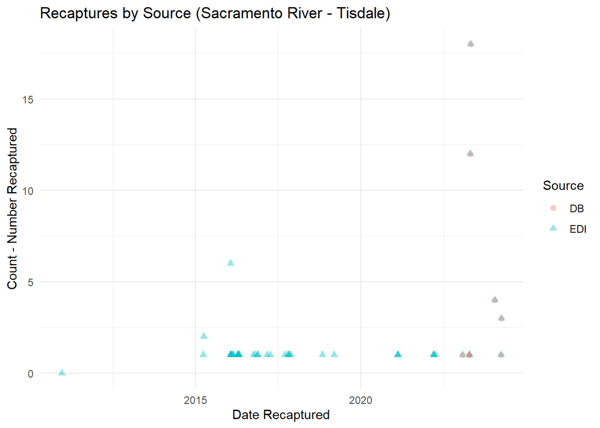

*fork_length*

- 100 % of values in the `fork_length` column from the database are NA.
- 56.5 % of values in the `forkLength` column from EDI are NA.

*lifestage*

- 0 % of values in the `lifestage_id` column from the database are NA.
- 0 % of values in the `lifeStage` column from EDI are NA.

[figure not shown]

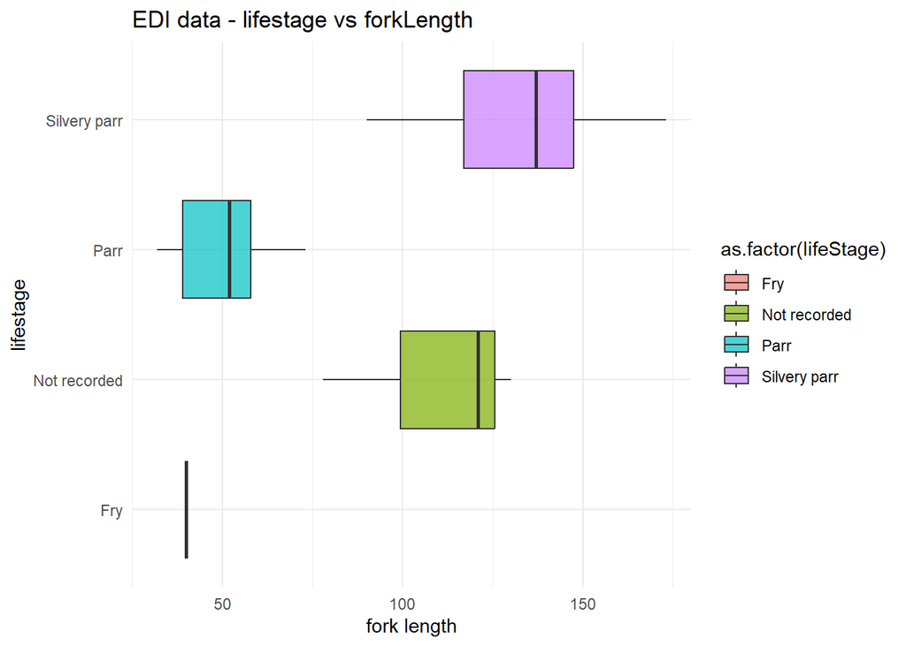

Random pick of data entry to compare between DB and EDI

- test 1

```
## Rows: 1
## Columns: 15
## $ id               <int> 248547
## $ trap_location_id <int> 55
## $ catch_raw_id     <int> 88918
## $ date             <date> 2024-03-29
## $ count            <dbl> 3
## $ run_id           <int> 2
## $ lifestage_id     <int> 6
## $ adipose_clipped  <lgl> FALSE
## $ dead             <lgl> TRUE
## $ fork_length      <dbl> NA
## $ weight           <dbl> NA
## $ release_id       <chr> "325"
## $ updated_at       <dttm> 2025-06-09 09:05:50
## $ stream           <chr> "sacramento river"
## $ source           <chr> "DB"
```

```
## Rows: 1
## Columns: 24
## $ ProjectDescriptionID <dbl> 10
## $ catchRawID           <dbl> 88918
## $ trapVisitID          <dbl> 7538
## $ commonName           <chr> "Chinook salmon"
## $ releaseID            <dbl> 325
## $ atCaptureRun         <chr> "Spring"
## $ finalRun             <chr> NA
## $ fishOrigin           <chr> "Natural"
## $ lifeStage            <chr> "Silvery parr"
## $ forkLength           <dbl> NA
## $ n                    <dbl> 3
## $ visitTime            <dttm> 2024-03-29 10:00:04
## $ visitTime2           <dttm> 2024-03-29 10:00:04
## $ visitType            <chr> "End trapping"
## $ siteName             <chr> "Tisdale Weir RST"
## $ subSiteName          <chr> "RR"
## $ markType             <chr> "Elastomer"
## $ markColor            <chr> "Red"
## $ markPosition         <chr> "Nose"
## $ trap_start_date      <dttm> 2024-03-27 10:00:13
## $ trap_end_date        <dttm> 2024-03-29 10:00:04
## $ source               <chr> "EDI"
## $ date                 <date> 2024-03-29
## $ count                <dbl> 3
```

- test 2

```
## Rows: 1
## Columns: 15
## $ id               <int> 248544
## $ trap_location_id <int> 55
## $ catch_raw_id     <int> 88914
## $ date             <date> 2023-04-26
## $ count            <dbl> 18
## $ run_id           <int> 6
## $ lifestage_id     <int> 4
## $ adipose_clipped  <lgl> TRUE
## $ dead             <lgl> TRUE
## $ fork_length      <dbl> NA
## $ weight           <dbl> NA
## $ release_id       <chr> "319"
## $ updated_at       <dttm> 2025-06-09 09:05:50
## $ stream           <chr> "sacramento river"
## $ source           <chr> "DB"
```

```
## Rows: 1
## Columns: 24
## $ ProjectDescriptionID <dbl> 10
## $ catchRawID           <dbl> 88914
## $ trapVisitID          <dbl> 7006
## $ commonName           <chr> "Chinook salmon"
## $ releaseID            <dbl> 319
## $ atCaptureRun         <chr> "Not recorded"
## $ finalRun             <chr> NA
## $ fishOrigin           <chr> "Hatchery"
## $ lifeStage            <chr> "Not recorded"
## $ forkLength           <dbl> NA
## $ n                    <dbl> 18
## $ visitTime            <dttm> 2023-04-26 10:00:39
## $ visitTime2           <dttm> 2023-04-26 10:00:39
## $ visitType            <chr> "Unplanned restart"
## $ siteName             <chr> "Tisdale Weir RST"
## $ subSiteName          <chr> "RR"
## $ markType             <chr> "Elastomer"
## $ markColor            <chr> "Red"
## $ markPosition         <chr> "Nose"
## $ trap_start_date      <dttm> 2023-04-20 09:45:14
## $ trap_end_date        <dttm> 2023-04-26 10:00:39
## $ source               <chr> "EDI"
## $ date                 <date> 2023-04-26
## $ count                <dbl> 18
```

- test 3

```
## Rows: 1
## Columns: 15
## $ id               <int> 248542
## $ trap_location_id <int> 55
## $ catch_raw_id     <int> 88906
## $ date             <date> 2023-04-13
## $ count            <dbl> 1
## $ run_id           <int> 6
## $ lifestage_id     <int> 4
## $ adipose_clipped  <lgl> FALSE
## $ dead             <lgl> TRUE
## $ fork_length      <dbl> NA
## $ weight           <dbl> NA
## $ release_id       <chr> "317"
## $ updated_at       <dttm> 2025-06-09 09:05:50
## $ stream           <chr> "sacramento river"
## $ source           <chr> "DB"
```

```
## Rows: 1
## Columns: 24
## $ ProjectDescriptionID <dbl> 10
## $ catchRawID           <dbl> 88906
## $ trapVisitID          <dbl> 6980
## $ commonName           <chr> "Chinook salmon"
## $ releaseID            <dbl> 317
## $ atCaptureRun         <chr> "Not recorded"
## $ finalRun             <chr> NA
## $ fishOrigin           <chr> "Natural"
## $ lifeStage            <chr> "Not recorded"
## $ forkLength           <dbl> NA
## $ n                    <dbl> 1
## $ visitTime            <dttm> 2023-04-13 09:45:52
## $ visitTime2           <dttm> 2023-04-13 09:45:52
## $ visitType            <chr> "Unplanned restart"
## $ siteName             <chr> "Tisdale Weir RST"
## $ subSiteName          <chr> "RR"
## $ markType             <chr> "Elastomer"
## $ markColor            <chr> "Pink"
## $ markPosition         <chr> "Nose"
## $ trap_start_date      <dttm> 2023-04-13 09:45:52
## $ trap_end_date        <dttm> 2023-04-13 09:45:52
## $ source               <chr> "EDI"
## $ date                 <date> 2023-04-13
## $ count                <dbl> 1
```

- test 4

```
## Rows: 1
## Columns: 15
## $ id               <int> 248540
## $ trap_location_id <int> 55
## $ catch_raw_id     <int> 88904
## $ date             <date> 2023-01-25
## $ count            <dbl> 1
## $ run_id           <int> 6
## $ lifestage_id     <int> 4
## $ adipose_clipped  <lgl> FALSE
## $ dead             <lgl> TRUE
## $ fork_length      <dbl> NA
## $ weight           <dbl> NA
## $ release_id       <chr> "283"
## $ updated_at       <dttm> 2025-06-09 09:05:50
## $ stream           <chr> "sacramento river"
## $ source           <chr> "DB"
```

```
## Rows: 1
## Columns: 24
## $ ProjectDescriptionID <dbl> 10
## $ catchRawID           <dbl> 88904
## $ trapVisitID          <dbl> 6829
## $ commonName           <chr> "Chinook salmon"
## $ releaseID            <dbl> 283
## $ atCaptureRun         <chr> "Not recorded"
## $ finalRun             <chr> NA
## $ fishOrigin           <chr> "Natural"
## $ lifeStage            <chr> "Not recorded"
## $ forkLength           <dbl> NA
## $ n                    <dbl> 1
## $ visitTime            <dttm> 2023-01-25 10:15:47
## $ visitTime2           <dttm> 2023-01-25 10:15:47
## $ visitType            <chr> "Continue trapping"
## $ siteName             <chr> "Tisdale Weir RST"
## $ subSiteName          <chr> "RR"
## $ markType             <chr> "Pigment / dye"
## $ markColor            <chr> "Brown"
## $ markPosition         <chr> "Whole body"
## $ trap_start_date      <dttm> 2022-04-01 10:45:52
## $ trap_end_date        <dttm> 2023-01-25 10:15:47
## $ source               <chr> "EDI"
## $ date                 <date> 2023-01-25
## $ count                <dbl> 1
```